# Relative deprivation in Trafford

###### Source: English Indices of Deprivation, MHCLG | @traffordDataLab

#### CIPFA

#### Change in percentage of LSOAs in 1st decile of Education, Skills and Training domain, CIPFA statistical neighbours

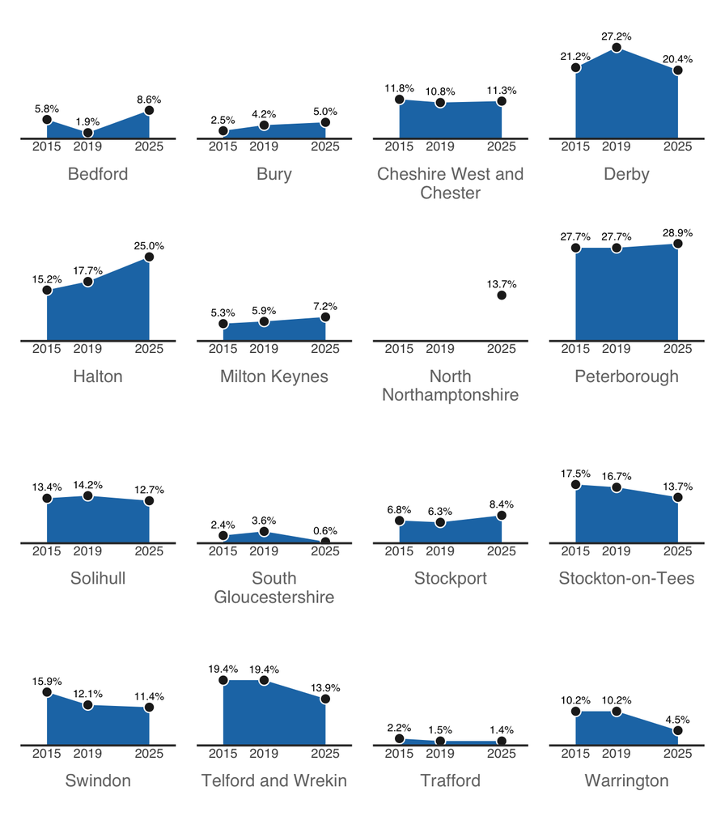

###### Source: English Indices of Deprivation, MHCLG | @traffordDataLab

#### NHS Peers

#### Change in percentage of LSOAs in 1st decile of Education, Skills and Training domain, NHS Near Neighbour peer group

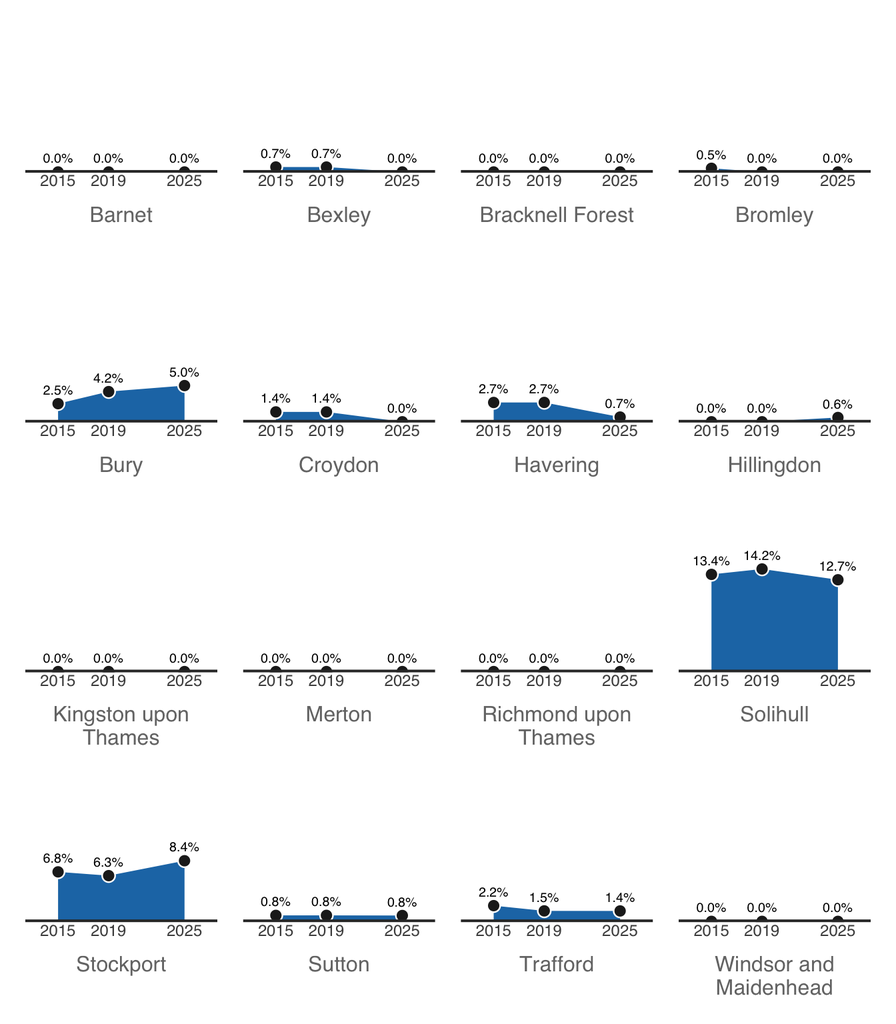

###### Source: English Indices of Deprivation, MHCLG | @traffordDataLab

2 LSOAs in Bucklow-St Martins ward were among the 10% most deprived LSOAs on the Education, Skills and Training domain in England in 2025.

#### Education, Skills and Training domain 2025, LSOAs in Trafford

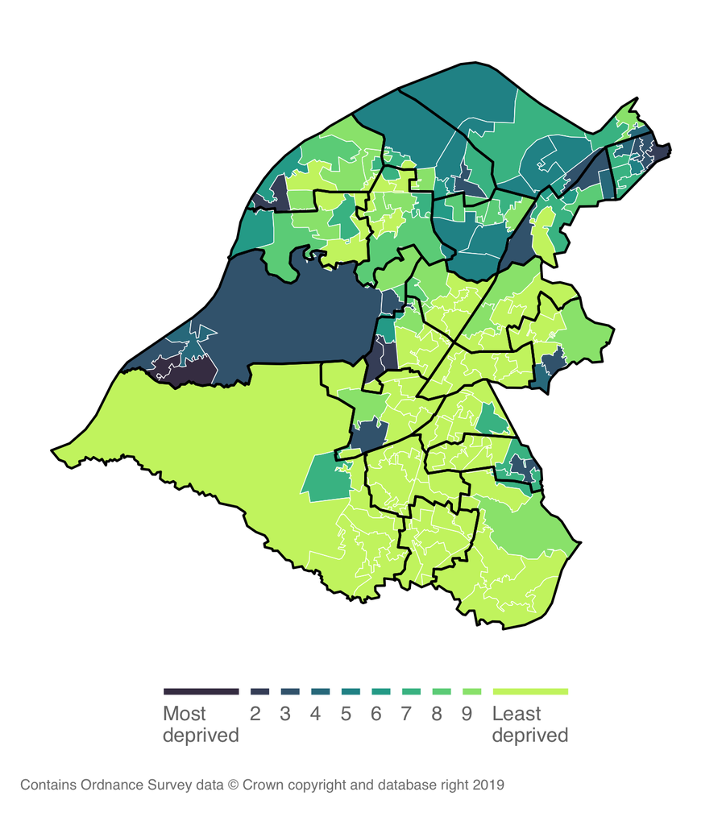

| LSOA | Ward | Decile | Rank |
| --- | --- | --- | --- |
| E01006108 | Bucklow-St Martins | 1 | 2,183 |
| E01006105 | Bucklow-St Martins | 1 | 3,102 |

Source: English Indices of Deprivation (2025), MHCLG | @traffordDataLab

#### Education, Skills and Training Deprivation 2025, LSOAs in Trafford

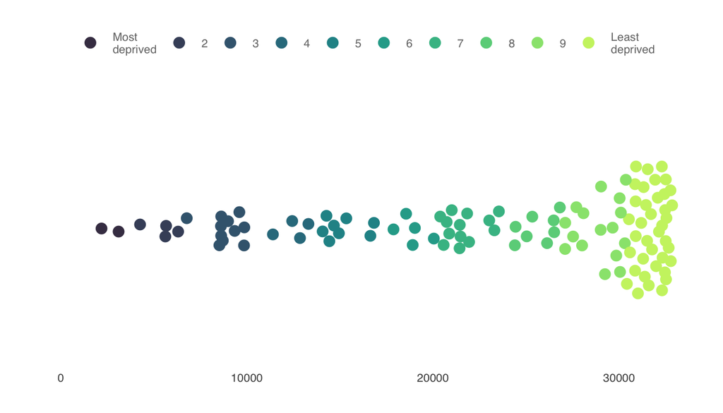

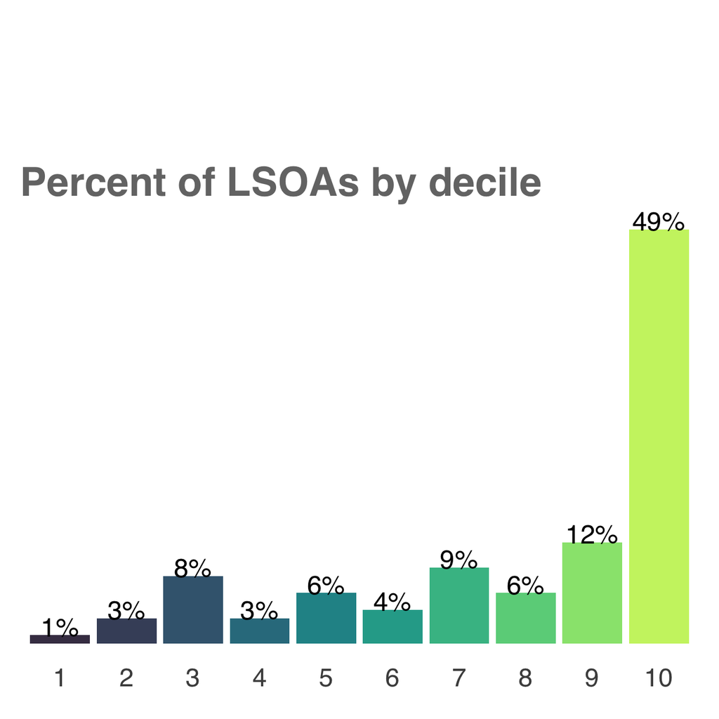

1 is most deprived  
Source: English Indices of Deprivation (2025), MHCLG | @traffordDataLab

The difference between the rank of the most deprived LSOA (2183) and the least deprived LSOA (33686) on the Index of Multiple Deprivation is 31503

12.2 % of the LSOAs in Trafford are among the 3 most deprived deciles in England, 66.2 % of the LSOAs in Trafford are among the 3 least deprived deciles in England

## Health and Disability

The Health and Disability domain measures the risk of premature death and the impairment of quality of life through poor physical or mental health.

Trafford is ranked 173 out of 317 local authorities in England on the average 2025 Health and Disability domain score. Trafford’s relative position was 147 out of 317 local authorities in 2019.

Click the tabs below for:

#### GM

#### Relative change in rank of average Health and Disability score, GM authorities

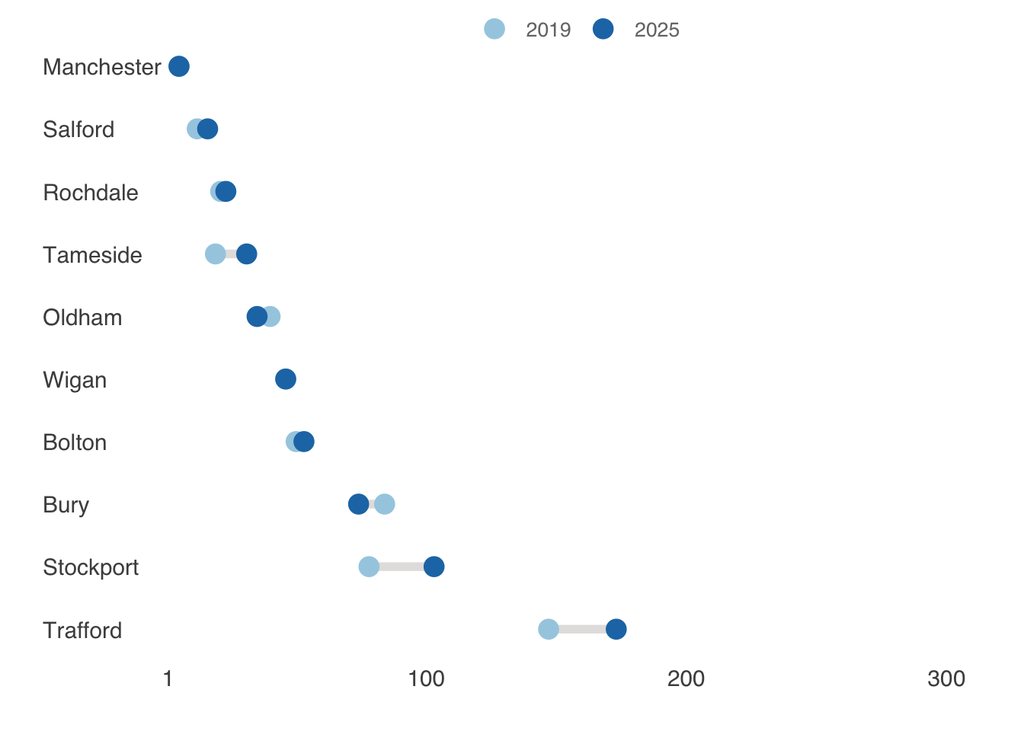

| Local authority | 2019 | 2025 | Change |
| --- | --- | --- | --- |
| Manchester | 5 | 5 | 0 |
| Salford | 12 | 16 | 4 |
| Rochdale | 21 | 23 | 2 |
| Tameside | 19 | 31 | 12 |
| Oldham | 40 | 35 | -5 |
| Wigan | 46 | 46 | 0 |
| Bolton | 50 | 53 | 3 |
| Bury | 84 | 74 | -10 |
| Stockport | 78 | 103 | 25 |
| Trafford | 147 | 173 | 26 |

Source: English Indices of Deprivation, MHCLG | @traffordDataLab

#### CIPFA

#### Relative change in rank of average Health and Disability score, CIPFA statistical neighbours

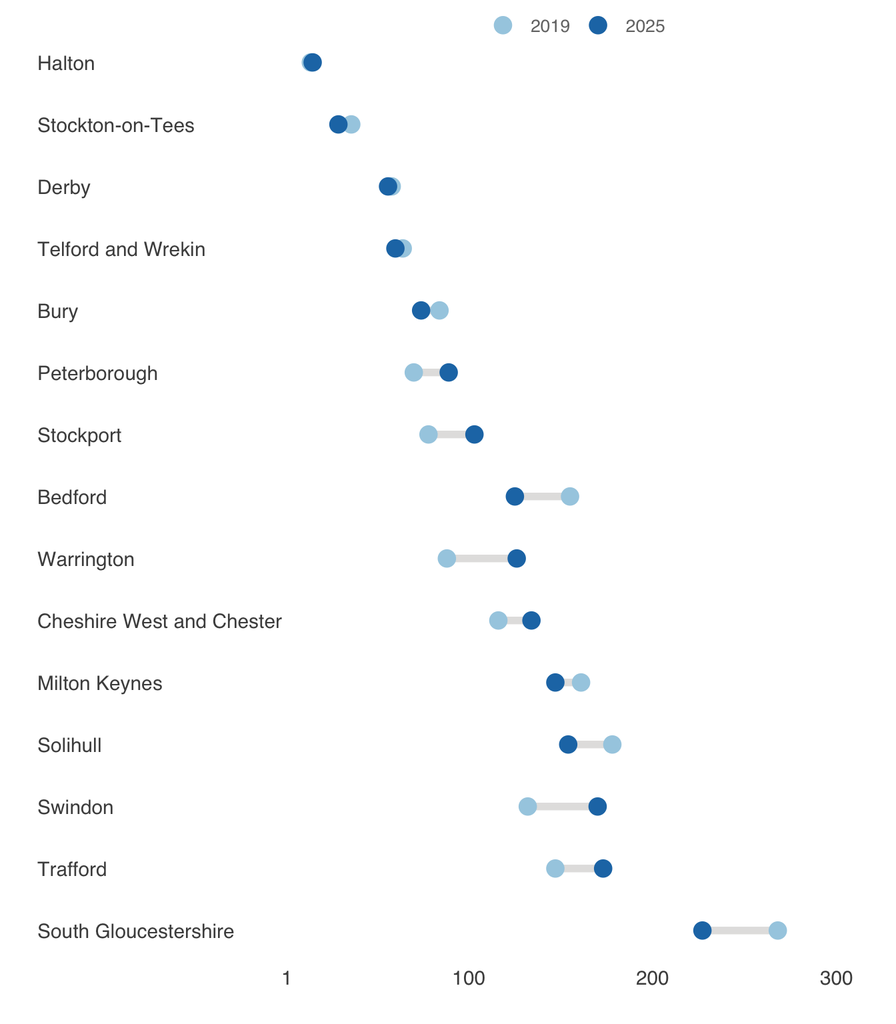

| Local authority | 2019 | 2025 | Change |
| --- | --- | --- | --- |
| Halton | 14 | 15 | 1 |
| Stockton-on-Tees | 36 | 29 | -7 |
| Derby | 58 | 56 | -2 |
| Telford and Wrekin | 64 | 60 | -4 |
| Bury | 84 | 74 | -10 |
| Peterborough | 70 | 89 | 19 |
| Stockport | 78 | 103 | 25 |
| Bedford | 155 | 125 | -30 |
| Warrington | 88 | 126 | 38 |
| North Northamptonshire | NA | 130 | NA |
| Cheshire West and Chester | 116 | 134 | 18 |
| Milton Keynes | 161 | 147 | -14 |
| Solihull | 178 | 154 | -24 |
| Swindon | 132 | 170 | 38 |
| Trafford | 147 | 173 | 26 |
| South Gloucestershire | 268 | 227 | -41 |

Source: English Indices of Deprivation, MHCLG | @traffordDataLab

#### NHS Peers

#### Relative change in rank of average Health and Disability score, NHS Near Neighbour peer group

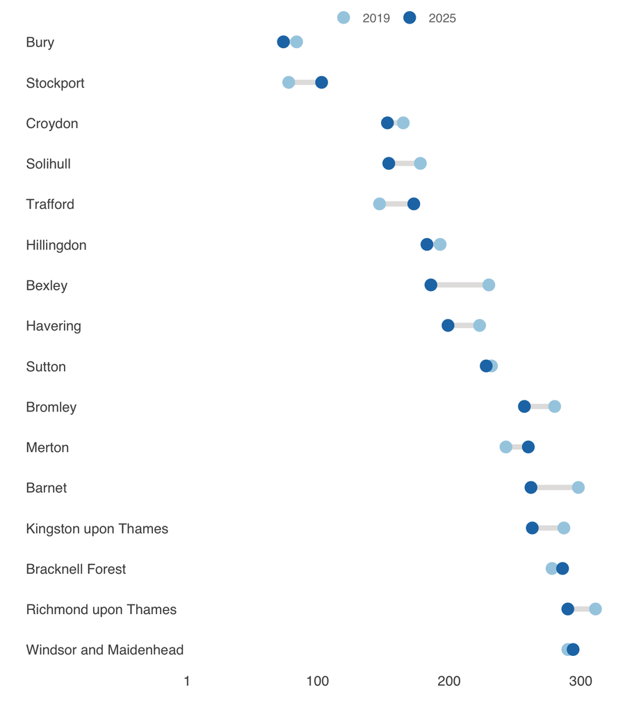

| Local authority | 2019 | 2025 | Change |
| --- | --- | --- | --- |
| Bury | 84 | 74 | -10 |
| Stockport | 78 | 103 | 25 |
| Croydon | 165 | 153 | -12 |
| Solihull | 178 | 154 | -24 |
| Trafford | 147 | 173 | 26 |
| Hillingdon | 193 | 183 | -10 |
| Bexley | 230 | 186 | -44 |
| Havering | 223 | 199 | -24 |
| Sutton | 232 | 228 | -4 |
| Bromley | 280 | 257 | -23 |
| Merton | 243 | 260 | 17 |
| Barnet | 298 | 262 | -36 |
| Kingston upon Thames | 287 | 263 | -24 |
| Bracknell Forest | 278 | 286 | 8 |
| Richmond upon Thames | 311 | 290 | -21 |
| Windsor and Maidenhead | 290 | 294 | 4 |

Source: English Indices of Deprivation, MHCLG | @traffordDataLab

The proportion of Trafford’s LSOAs ranked in the 1st decile or 10% most deprived in England was 4.3% (6 out of 139) in 2025. This represents a decline in relative deprivation since 2019 when 5.1% (7 out of 138) of LSOAs were ranked within the 1st decile.

Click the tabs below for:

#### GM

#### Change in percentage of LSOAs in 1st decile of Health and Disability domain, GM authorities

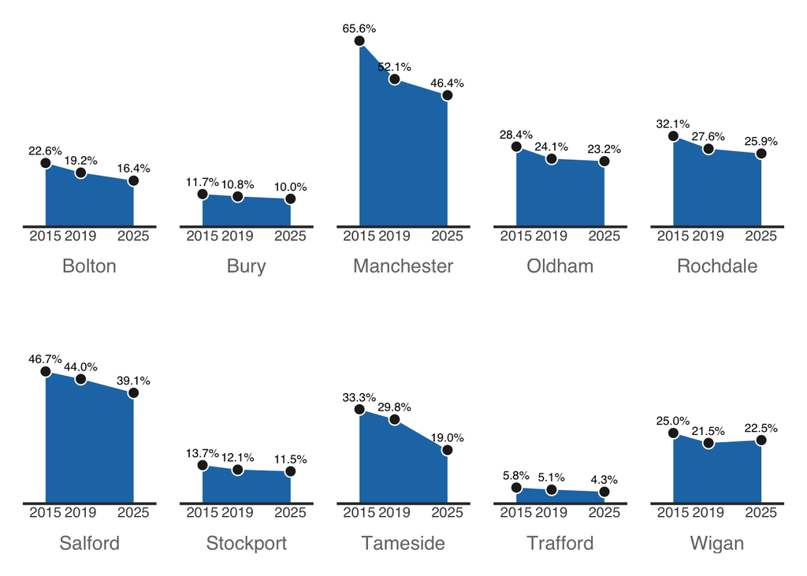

###### Source: English Indices of Deprivation, MHCLG | @traffordDataLab

#### CIPFA

#### Change in percentage of LSOAs in 1st decile of Health and Disability domain, CIPFA statistical neighbours

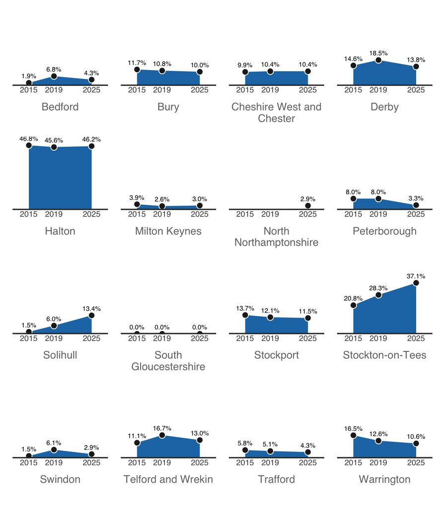

###### Source: English Indices of Deprivation, MHCLG | @traffordDataLab

#### NHS Peers

#### Change in percentage of LSOAs in 1st decile of Health and Disability domain, NHS Near Neighbour peer group

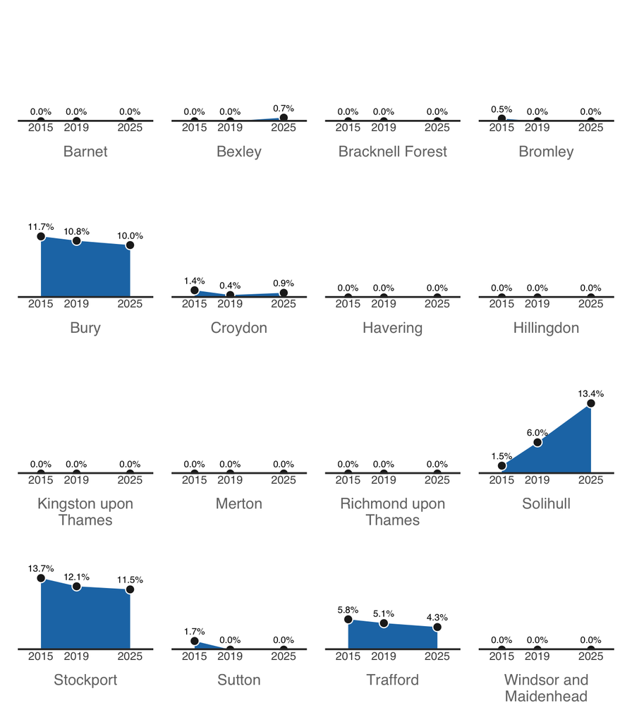

#### Health and Disability domain 2025, LSOAs in Trafford

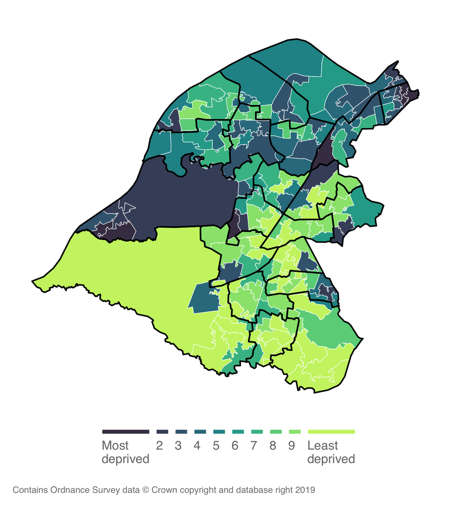

| LSOA | Ward | Decile | Rank |
| --- | --- | --- | --- |
| E01006109 | Old Trafford | 1 | 1,272 |
| E01006108 | Bucklow-St Martins | 1 | 1,556 |
| E01006105 | Bucklow-St Martins | 1 | 2,092 |
| E01006144 | Longford | 1 | 2,314 |
| E01006168 | Manor | 1 | 2,480 |
| E01006112 | Old Trafford | 1 | 2,486 |

Source: English Indices of Deprivation (2025), MHCLG | @traffordDataLab

#### Health and Disability Deprivation 2025, LSOAs in Trafford

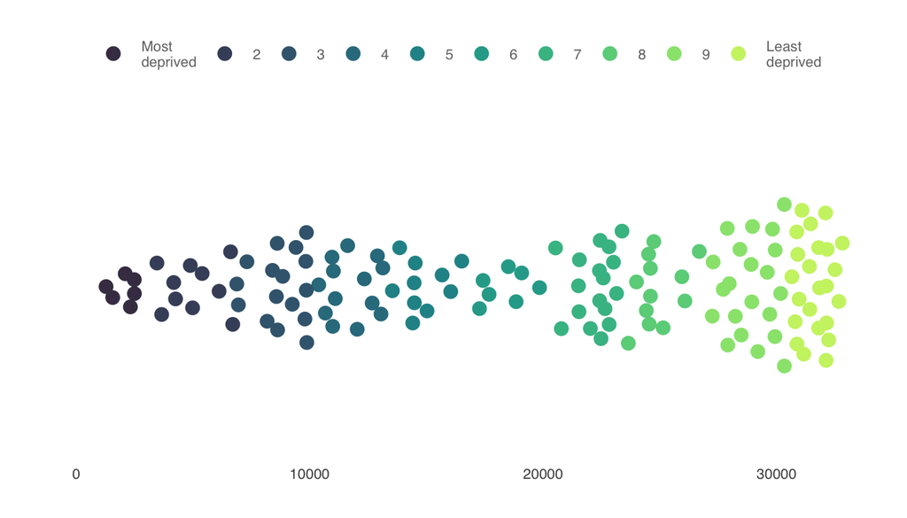

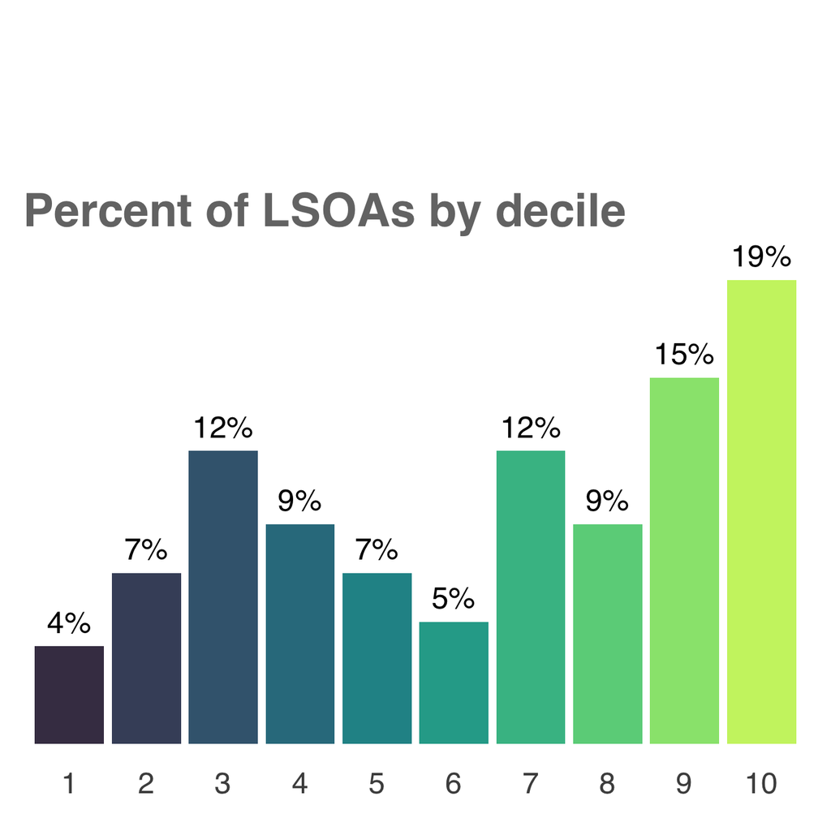

1 is most deprived  
Source: English Indices of Deprivation (2025), MHCLG | @traffordDataLab

The difference between the rank of the most deprived LSOA (1272) and the least deprived LSOA (33410) on the Index of Multiple Deprivation is 32138

23 % of the LSOAs in Trafford are among the 3 most deprived deciles in England, 43.2 % of the LSOAs in Trafford are among the 3 least deprived deciles in England

## Crime

The Crime domain measures the risk of personal and material victimisation at a local level.

Trafford is ranked 140 out of 317 local authorities in England on the average 2025 Crime domain score. Trafford’s relative position was 138 out of 317 local authorities in 2019.

Click the tabs below for:

#### GM

#### Relative change in rank of average Crime score, GM authorities

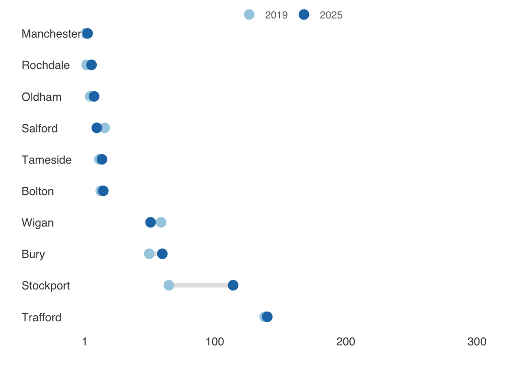

| Local authority | 2019 | 2025 | Change |
| --- | --- | --- | --- |
| Manchester | 1 | 3 | 2 |
| Rochdale | 2 | 6 | 4 |
| Oldham | 5 | 8 | 3 |
| Salford | 16 | 10 | -6 |
| Tameside | 12 | 14 | 2 |
| Bolton | 13 | 15 | 2 |
| Wigan | 59 | 51 | -8 |
| Bury | 50 | 60 | 10 |
| Stockport | 65 | 114 | 49 |
| Trafford | 138 | 140 | 2 |

Source: English Indices of Deprivation, MHCLG | @traffordDataLab

#### CIPFA

#### Relative change in rank of average Crime score, CIPFA statistical neighbours

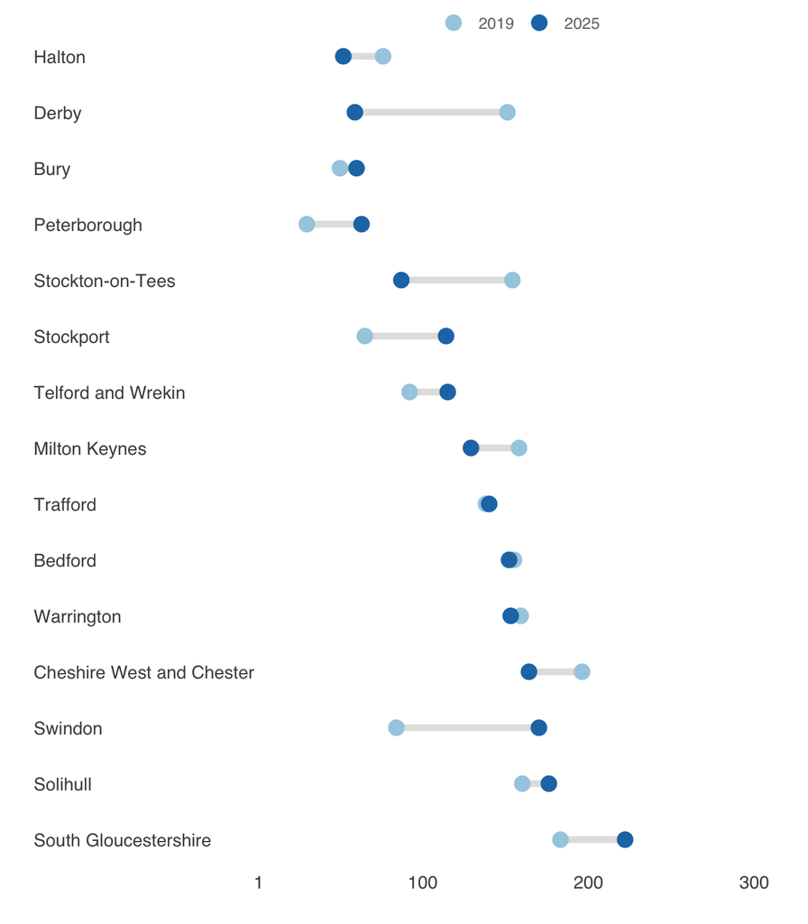

| Local authority | 2019 | 2025 | Change |
| --- | --- | --- | --- |
| Halton | 76 | 52 | -24 |
| Derby | 151 | 59 | -92 |
| Bury | 50 | 60 | 10 |
| Peterborough | 30 | 63 | 33 |
| Stockton-on-Tees | 154 | 87 | -67 |
| Stockport | 65 | 114 | 49 |
| Telford and Wrekin | 92 | 115 | 23 |
| North Northamptonshire | NA | 128 | NA |
| Milton Keynes | 158 | 129 | -29 |
| Trafford | 138 | 140 | 2 |
| Bedford | 155 | 152 | -3 |
| Warrington | 159 | 153 | -6 |
| Cheshire West and Chester | 196 | 164 | -32 |
| Swindon | 84 | 170 | 86 |
| Solihull | 160 | 176 | 16 |
| South Gloucestershire | 183 | 222 | 39 |

Source: English Indices of Deprivation, MHCLG | @traffordDataLab

#### NHS Peers

#### Relative change in rank of average Crime score, NHS Near Neighbour peer group

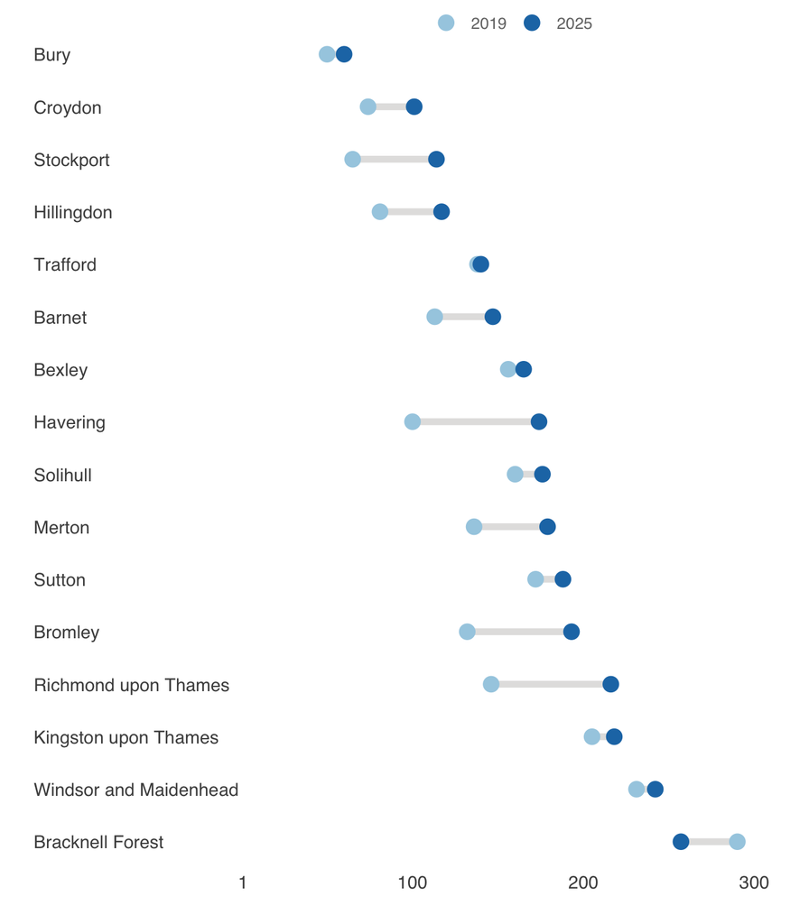

| Local authority | 2019 | 2025 | Change |
| --- | --- | --- | --- |
| Bury | 50 | 60 | 10 |
| Croydon | 74 | 101 | 27 |
| Stockport | 65 | 114 | 49 |
| Hillingdon | 81 | 117 | 36 |
| Trafford | 138 | 140 | 2 |
| Barnet | 113 | 147 | 34 |
| Bexley | 156 | 165 | 9 |
| Havering | 100 | 174 | 74 |
| Solihull | 160 | 176 | 16 |
| Merton | 136 | 179 | 43 |
| Sutton | 172 | 188 | 16 |
| Bromley | 132 | 193 | 61 |
| Richmond upon Thames | 146 | 216 | 70 |
| Kingston upon Thames | 205 | 218 | 13 |
| Windsor and Maidenhead | 231 | 242 | 11 |
| Bracknell Forest | 290 | 257 | -33 |

Source: English Indices of Deprivation, MHCLG | @traffordDataLab

The proportion of Trafford’s LSOAs ranked in the 1st decile or 10% most deprived in England was 5.8% (8 out of 139) in 2025. This represents a relative increase compared to 2019 when 2.2% (3 out of 138) of LSOAs were ranked within the 1st decile.

Click the tabs below for:

#### GM

#### Change in percentage of LSOAs in 1st decile of Crime domain, GM authorities

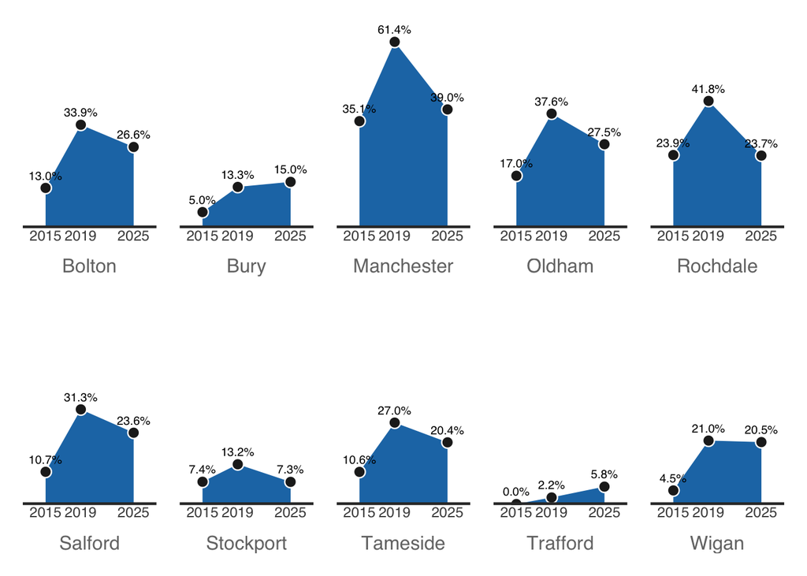

###### Source: English Indices of Deprivation, MHCLG | @traffordDataLab

#### CIPFA

#### Change in percentage of LSOAs in 1st decile of Crime domain, CIPFA statistical neighbours

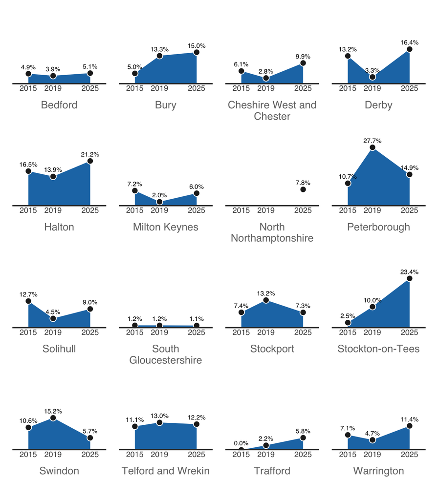

###### Source: English Indices of Deprivation, MHCLG | @traffordDataLab

#### NHS Peers

#### Change in percentage of LSOAs in 1st decile of Crime domain, NHS Near Neighbour peer group

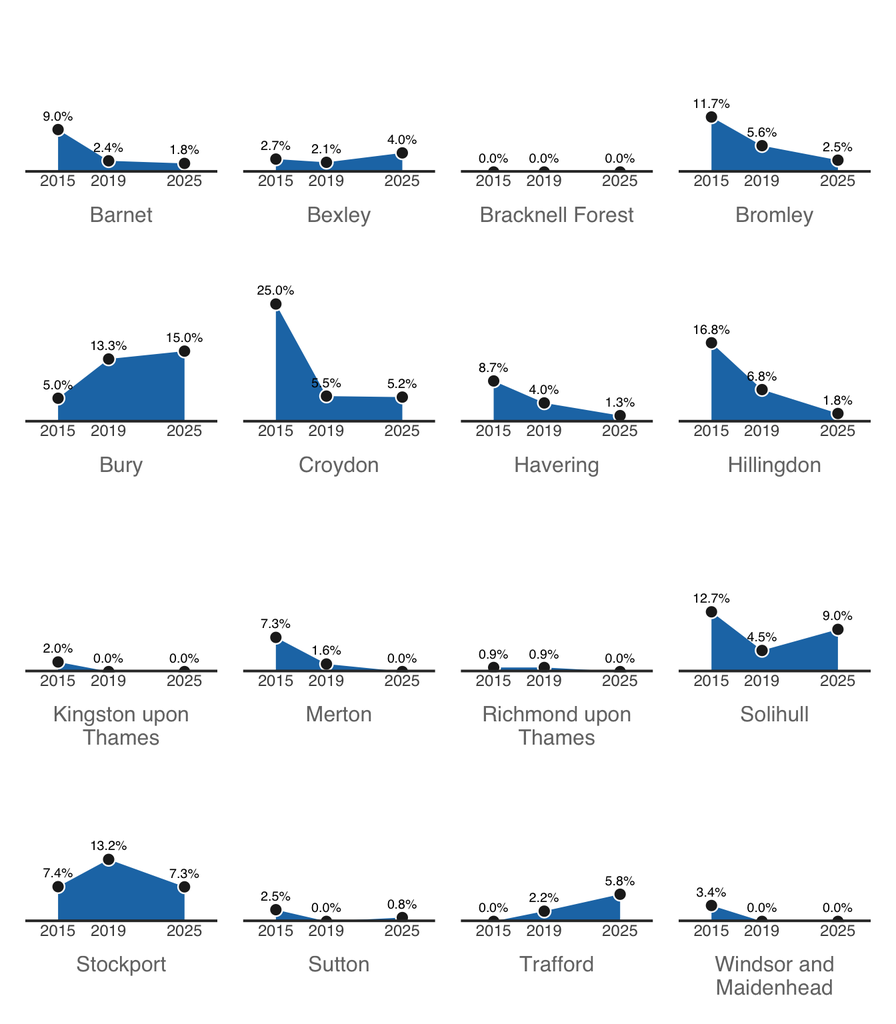

#### Crime domain 2025, LSOAs in Trafford

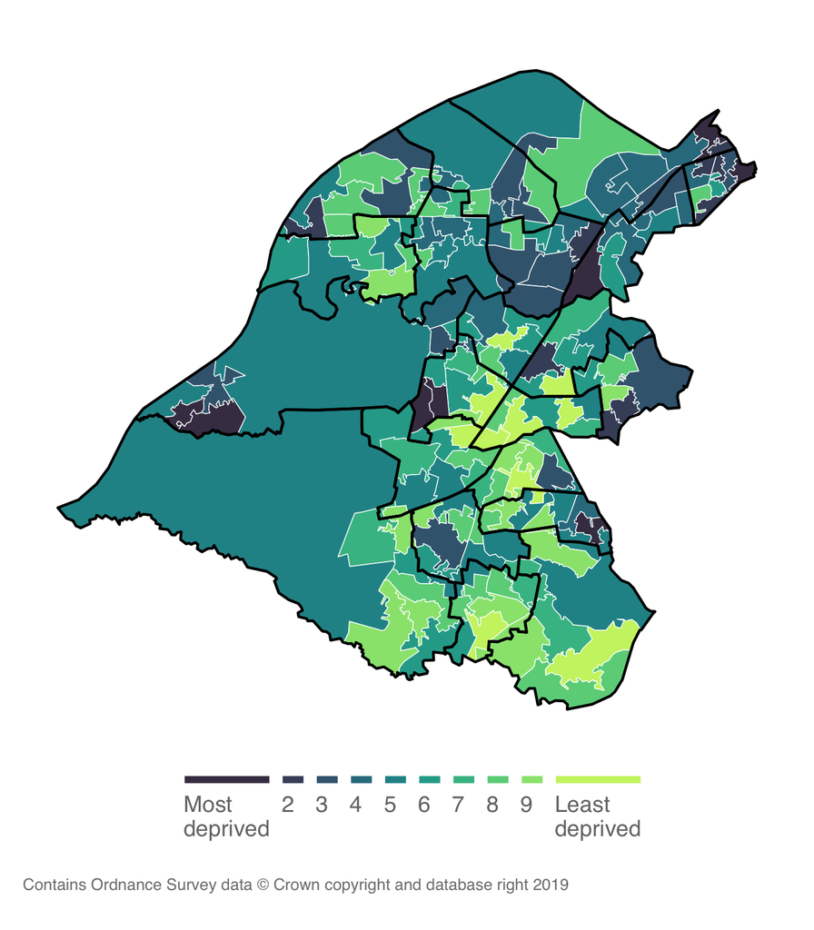

| LSOA | Ward | Decile | Rank |
| --- | --- | --- | --- |
| E01006109 | Old Trafford | 1 | 425 |
| E01006108 | Bucklow-St Martins | 1 | 1,282 |
| E01006144 | Longford | 1 | 1,324 |
| E01006105 | Bucklow-St Martins | 1 | 1,680 |
| E01006207 | Timperley Central | 1 | 2,753 |
| E01034000 | Gorse Hill & Cornbrook | 1 | 2,905 |
| E01006167 | Manor | 1 | 3,125 |
| E01006168 | Manor | 1 | 3,204 |

Source: English Indices of Deprivation (2025), MHCLG | @traffordDataLab

#### Crime Deprivation 2025, LSOAs in Trafford

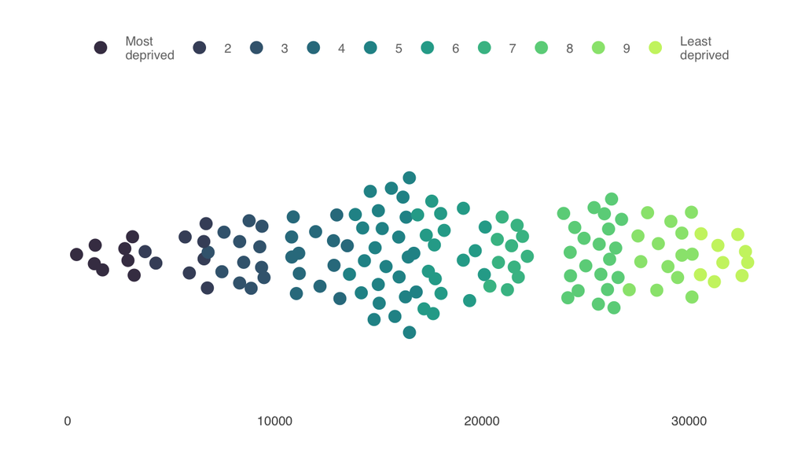

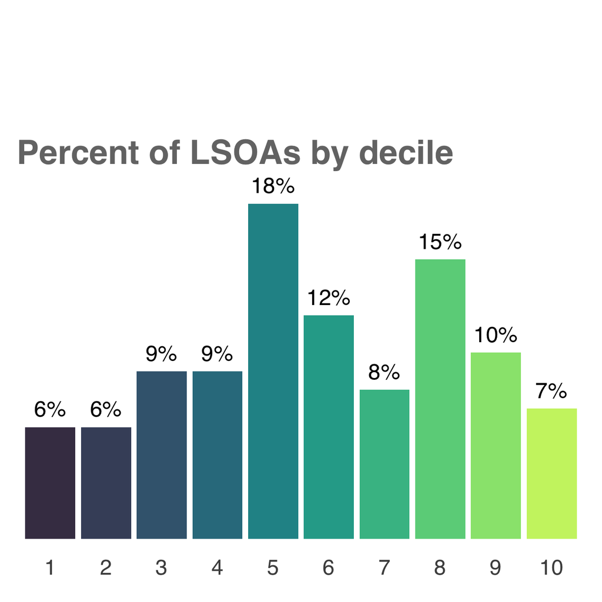

1 is most deprived  
Source: English Indices of Deprivation (2025), MHCLG | @traffordDataLab

The difference between the rank of the most deprived LSOA (425) and the least deprived LSOA (33150) on the Index of Multiple Deprivation is 32725

20.1 % of the LSOAs in Trafford are among the 3 most deprived deciles in England, 32.4 % of the LSOAs in Trafford are among the 3 least deprived deciles in England

## Barriers to Housing and Services

The Barriers to Housing and Services domain measures the physical and financial accessibility of housing and local services.

Trafford is ranked 287 out of 317 local authorities in England on the average 2025 Barriers to Housing and Services domain score. Trafford’s relative position was 289 out of 317 local authorities in 2019.

Click the tabs below for:

#### GM

#### Relative change in rank of average Barriers to Housing and Services score, GM authorities

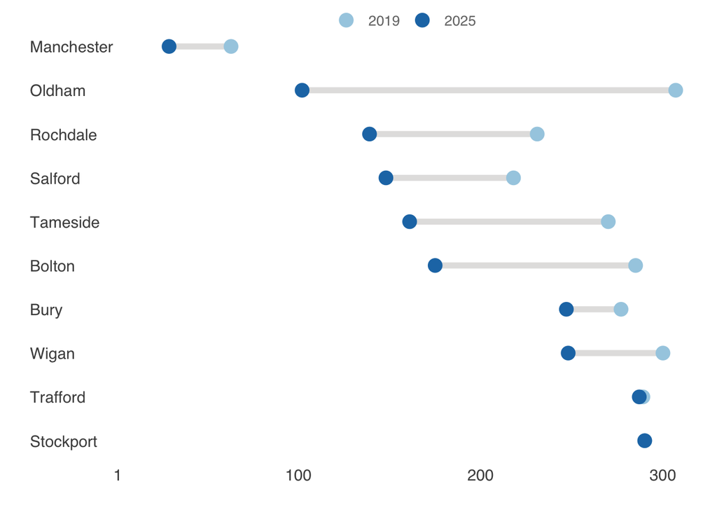

| Local authority | 2019 | 2025 | Change |
| --- | --- | --- | --- |
| Manchester | 63 | 29 | -34 |
| Oldham | 307 | 102 | -205 |
| Rochdale | 231 | 139 | -92 |
| Salford | 218 | 148 | -70 |
| Tameside | 270 | 161 | -109 |
| Bolton | 285 | 175 | -110 |
| Bury | 277 | 247 | -30 |
| Wigan | 300 | 248 | -52 |
| Trafford | 289 | 287 | -2 |
| Stockport | 290 | 290 | 0 |

Source: English Indices of Deprivation, MHCLG | @traffordDataLab

#### CIPFA

#### Relative change in rank of average Barriers to Housing and Services score, CIPFA statistical neighbours

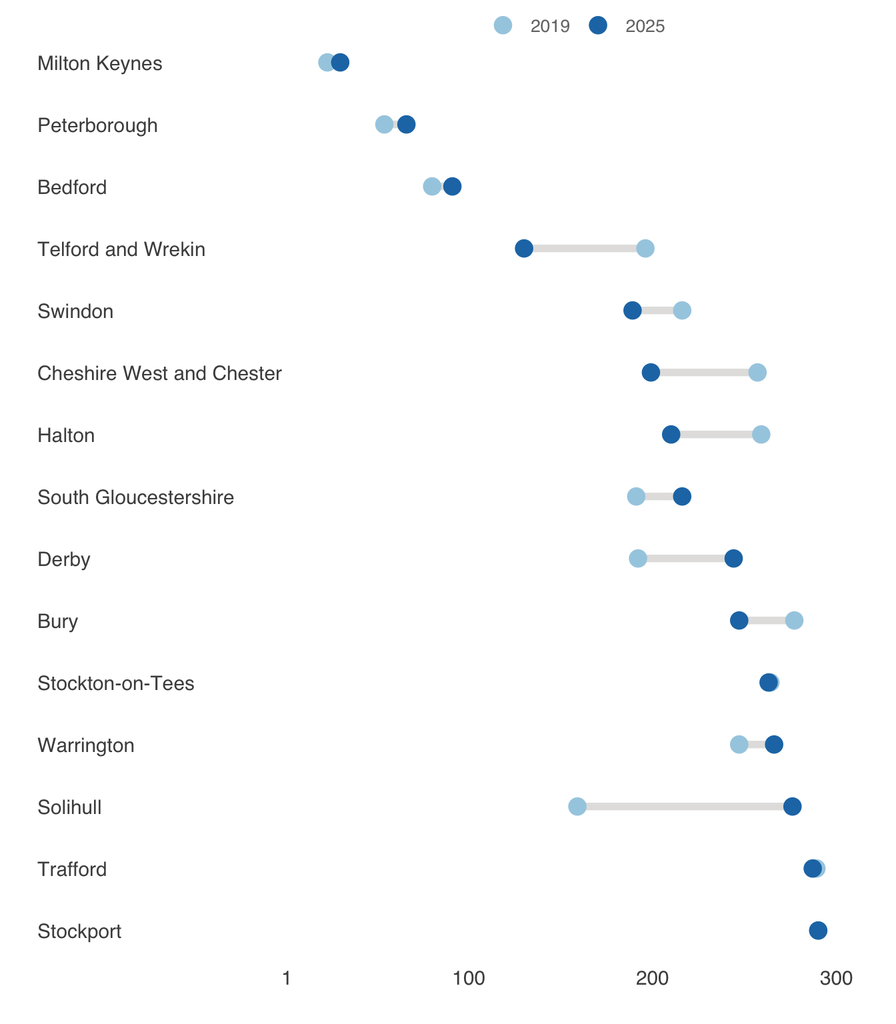

| Local authority | 2019 | 2025 | Change |
| --- | --- | --- | --- |
| Milton Keynes | 23 | 30 | 7 |
| Peterborough | 54 | 66 | 12 |
| Bedford | 80 | 91 | 11 |
| Telford and Wrekin | 196 | 130 | -66 |
| Swindon | 216 | 189 | -27 |
| Cheshire West and Chester | 257 | 199 | -58 |
| Halton | 259 | 210 | -49 |
| South Gloucestershire | 191 | 216 | 25 |
| North Northamptonshire | NA | 219 | NA |
| Derby | 192 | 244 | 52 |
| Bury | 277 | 247 | -30 |
| Stockton-on-Tees | 264 | 263 | -1 |
| Warrington | 247 | 266 | 19 |
| Solihull | 159 | 276 | 117 |
| Trafford | 289 | 287 | -2 |
| Stockport | 290 | 290 | 0 |

Source: English Indices of Deprivation, MHCLG | @traffordDataLab

#### NHS Peers

#### Relative change in rank of average Barriers to Housing and Services score, NHS Near Neighbour peer group

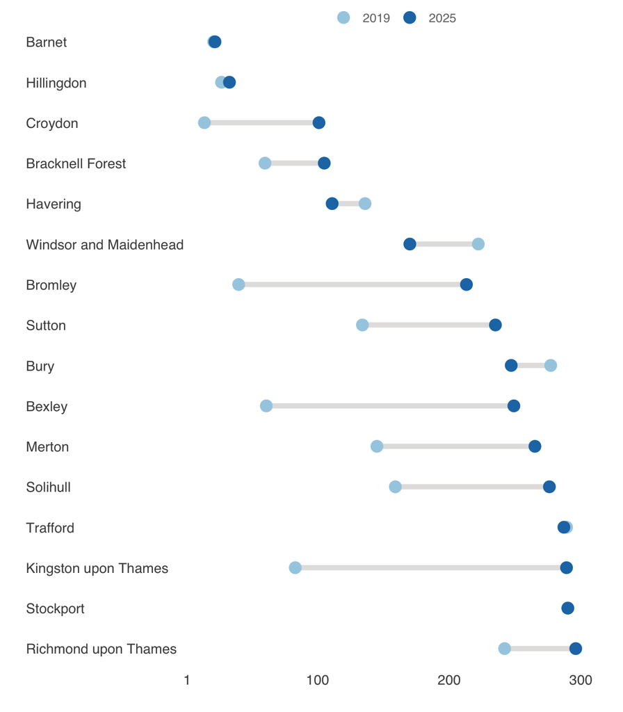

| Local authority | 2019 | 2025 | Change |
| --- | --- | --- | --- |
| Barnet | 21 | 22 | 1 |
| Hillingdon | 27 | 33 | 6 |
| Croydon | 14 | 101 | 87 |
| Bracknell Forest | 60 | 105 | 45 |
| Havering | 136 | 111 | -25 |
| Windsor and Maidenhead | 222 | 170 | -52 |
| Bromley | 40 | 213 | 173 |
| Sutton | 134 | 235 | 101 |
| Bury | 277 | 247 | -30 |
| Bexley | 61 | 249 | 188 |
| Merton | 145 | 265 | 120 |
| Solihull | 159 | 276 | 117 |
| Trafford | 289 | 287 | -2 |
| Kingston upon Thames | 83 | 289 | 206 |
| Stockport | 290 | 290 | 0 |
| Richmond upon Thames | 242 | 296 | 54 |

Source: English Indices of Deprivation, MHCLG | @traffordDataLab

None of the Trafford’s LSOAs ranked in the 1st decile or 10% most deprived in England in 2025. This represents a decrease compared to 2019 when 0.7% (1 out of 138) of LSOAs were ranked within the 1st decile.

Click the tabs below for:

#### GM

#### Change in percentage of LSOAs in 1st decile of Barriers to Housing and Services domain, GM authorities

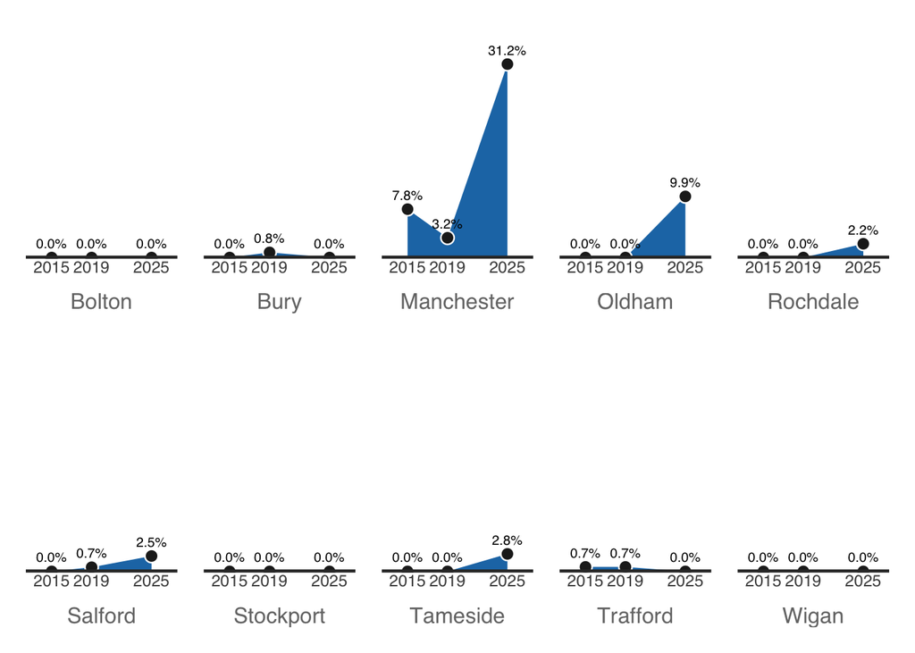

###### Source: English Indices of Deprivation, MHCLG | @traffordDataLab

#### CIPFA

#### Change in percentage of LSOAs in 1st decile of Barriers to Housing and Services domain, CIPFA statistical neighbours

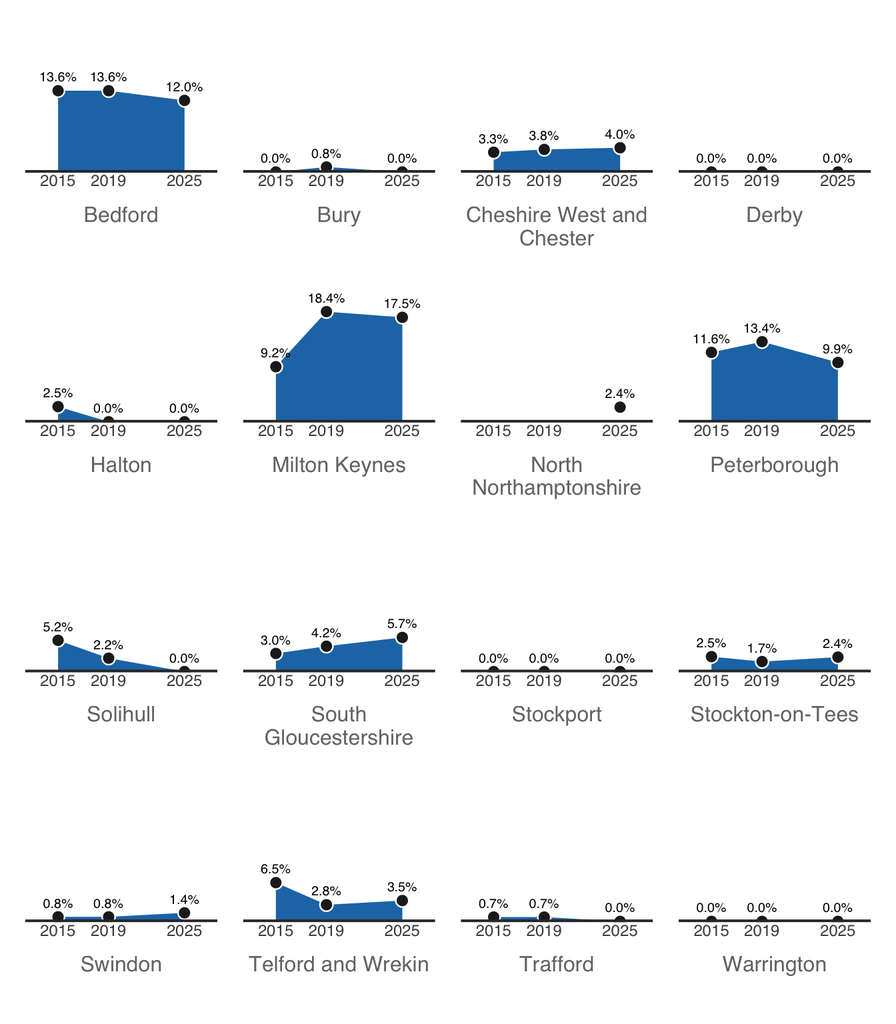

###### Source: English Indices of Deprivation, MHCLG | @traffordDataLab

#### NHS Peers

#### Change in percentage of LSOAs in 1st decile of Barriers to Housing and Services domain, NHS Near Neighbour peer group

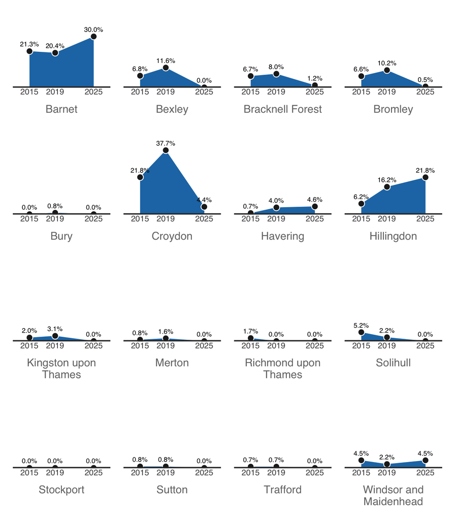

###### Source: English Indices of Deprivation, MHCLG | @traffordDataLab

There are no LSOA in Trafford amongst the 10% most deprived LSOAs on the Barriers to Housing and Services domain in England in 2025.

#### Barriers to Housing and Services domain 2025, LSOAs in Trafford

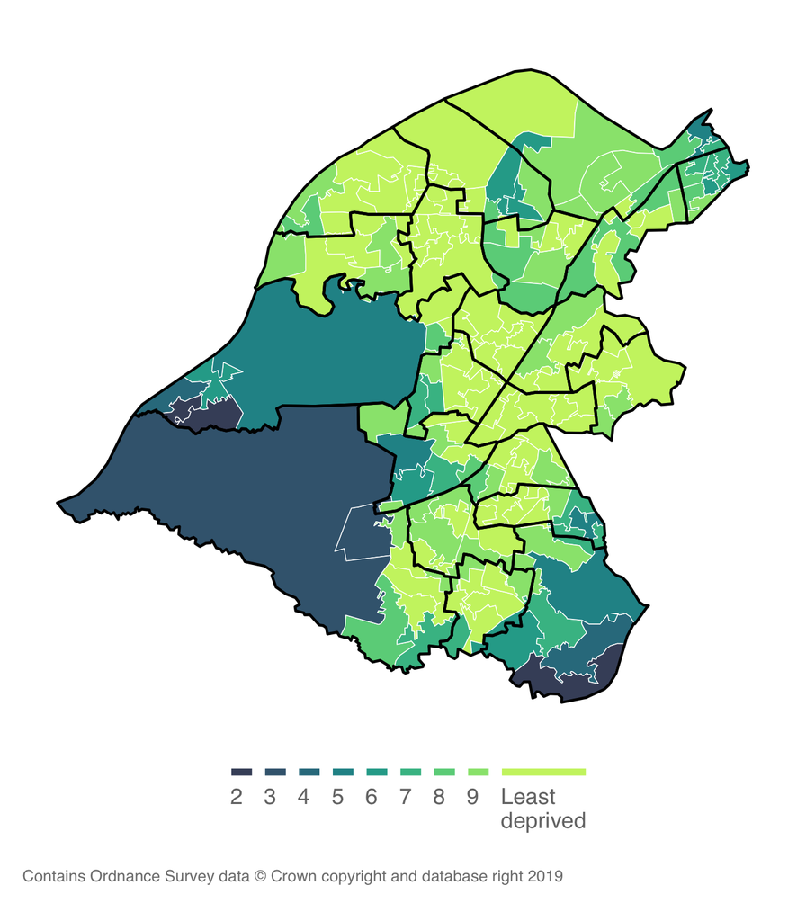

Source: English Indices of Deprivation (2025), MHCLG | @traffordDataLab

#### Barriers to Housing and Services Deprivation 2025, LSOAs in Trafford

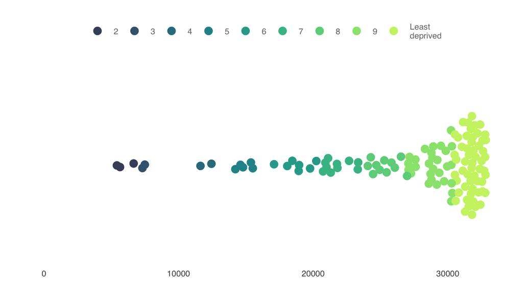

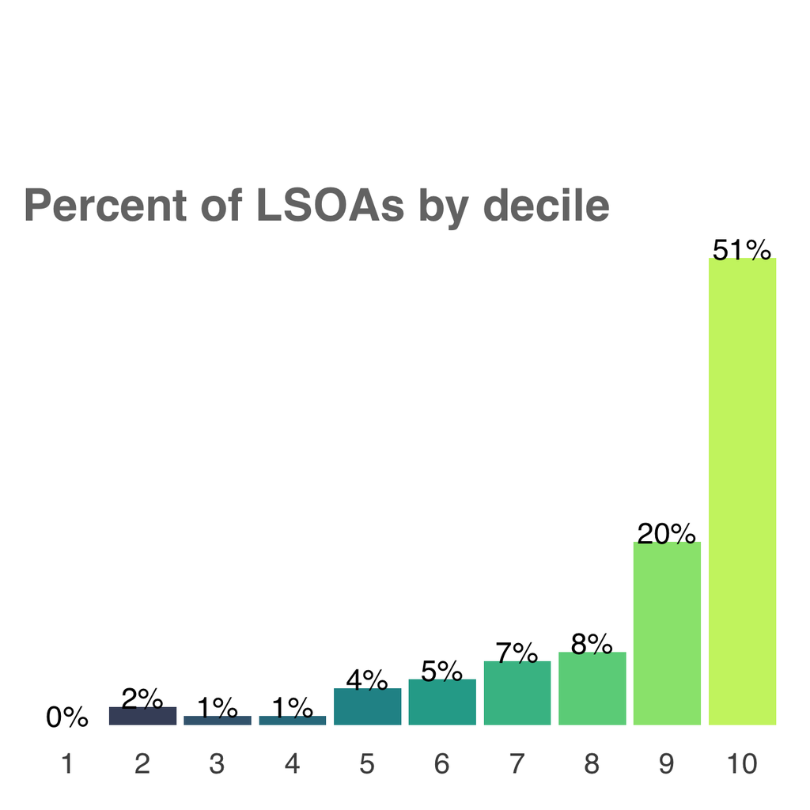

1 is most deprived  
Source: English Indices of Deprivation (2025), MHCLG | @traffordDataLab

The difference between the rank of the most deprived LSOA (5413) and the least deprived LSOA (33438) on the Index of Multiple Deprivation is 28025

3.6 % of the LSOAs in Trafford are among the 3 most deprived deciles in England, 79.1 % of the LSOAs in Trafford are among the 3 least deprived deciles in England

## Living Environment

The Living Environment domain measures the quality of the local environment. This includes an ‘indoors’ (Housing in poor condition, Housing Energy Performance Score, Housing lacking private outdoor space) and an ‘outdoors’ (Air quality, Road traffic accidents and Noise pollution) subdomain.

The lowest rank of Trafford was on the Living environment deprivation domain ranking 79 among local authorities in 2025, the largest change from 2019 when Trafford ranked 131. These may be due to the change in datasets with the introduction of the Housing Energy Performance Score, Housing Energy Performance Score and Noise pollution, and elimination of Houses without central heating.

Click the tabs below for:

#### GM

#### Relative change in rank of average Living Environment score, GM authorities

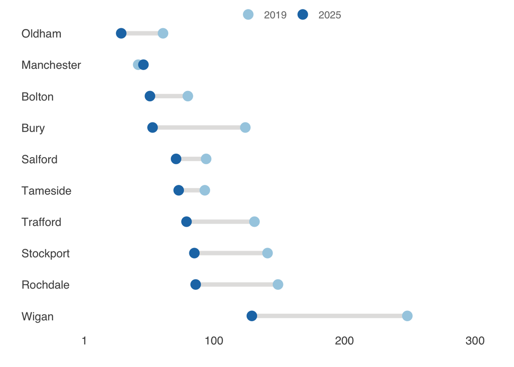

| Local authority | 2019 | 2025 | Change |
| --- | --- | --- | --- |
| Oldham | 61 | 29 | -32 |
| Manchester | 42 | 46 | 4 |
| Bolton | 80 | 51 | -29 |
| Bury | 124 | 53 | -71 |
| Salford | 94 | 71 | -23 |
| Tameside | 93 | 73 | -20 |
| Trafford | 131 | 79 | -52 |
| Stockport | 141 | 85 | -56 |
| Rochdale | 149 | 86 | -63 |
| Wigan | 248 | 129 | -119 |

Source: English Indices of Deprivation, MHCLG | @traffordDataLab

#### CIPFA

#### Relative change in rank of average Living Environment score, CIPFA statistical neighbours

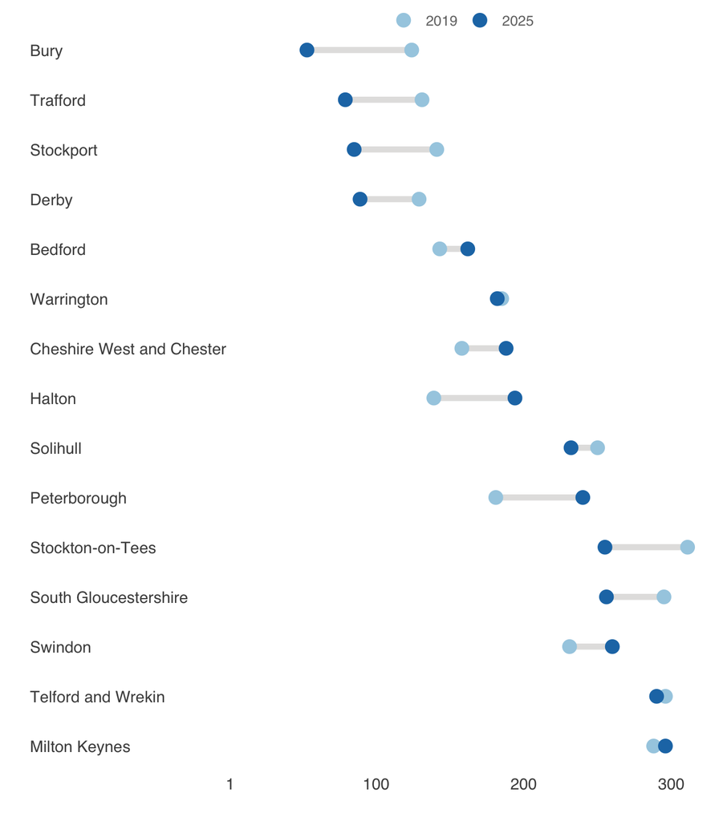

| Local authority | 2019 | 2025 | Change |
| --- | --- | --- | --- |
| Bury | 124 | 53 | -71 |
| Trafford | 131 | 79 | -52 |
| Stockport | 141 | 85 | -56 |
| Derby | 129 | 89 | -40 |
| Bedford | 143 | 162 | 19 |
| Warrington | 185 | 182 | -3 |
| Cheshire West and Chester | 158 | 188 | 30 |
| Halton | 139 | 194 | 55 |
| Solihull | 250 | 232 | -18 |
| North Northamptonshire | NA | 239 | NA |
| Peterborough | 181 | 240 | 59 |
| Stockton-on-Tees | 311 | 255 | -56 |
| South Gloucestershire | 295 | 256 | -39 |
| Swindon | 231 | 260 | 29 |
| Telford and Wrekin | 296 | 290 | -6 |
| Milton Keynes | 288 | 296 | 8 |

Source: English Indices of Deprivation, MHCLG | @traffordDataLab

#### NHS Peers

#### Relative change in rank of average Living Environment score, NHS Near Neighbour peer group

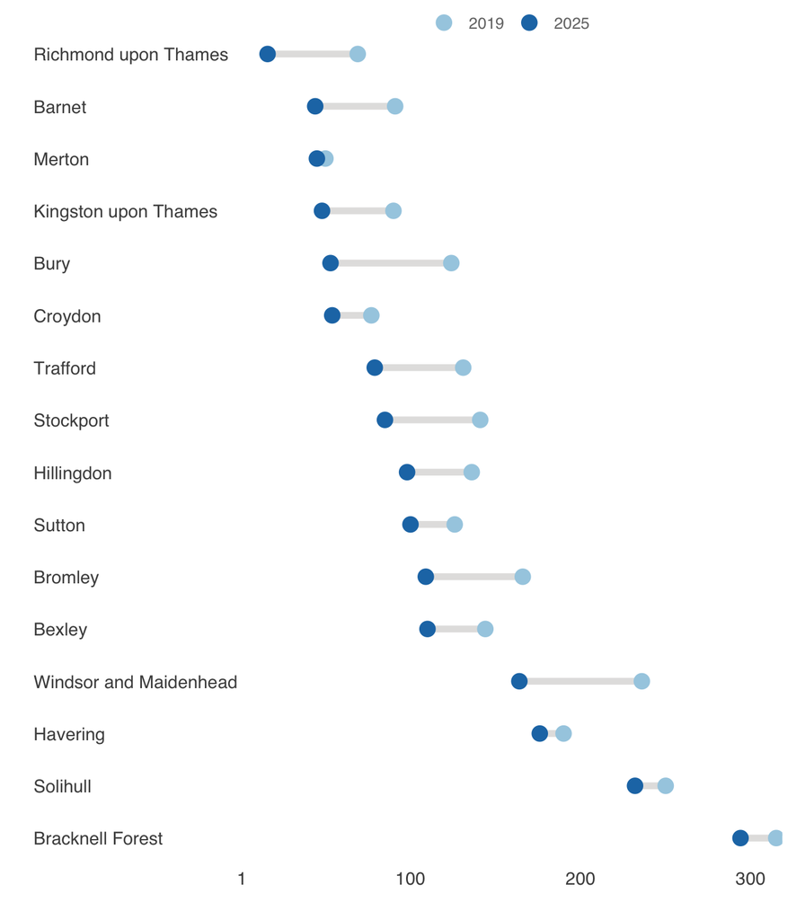

| Local authority | 2019 | 2025 | Change |
| --- | --- | --- | --- |
| Richmond upon Thames | 69 | 16 | -53 |
| Barnet | 91 | 44 | -47 |
| Merton | 50 | 45 | -5 |
| Kingston upon Thames | 90 | 48 | -42 |
| Bury | 124 | 53 | -71 |
| Croydon | 77 | 54 | -23 |
| Trafford | 131 | 79 | -52 |
| Stockport | 141 | 85 | -56 |
| Hillingdon | 136 | 98 | -38 |
| Sutton | 126 | 100 | -26 |
| Bromley | 166 | 109 | -57 |
| Bexley | 144 | 110 | -34 |
| Windsor and Maidenhead | 236 | 164 | -72 |
| Havering | 190 | 176 | -14 |
| Solihull | 250 | 232 | -18 |
| Bracknell Forest | 315 | 294 | -21 |

Source: English Indices of Deprivation, MHCLG | @traffordDataLab

The proportion of Trafford’s LSOAs ranked in the 1st decile or 10% most deprived in England was 5.8% (8 out of 139) in 2025. This represents a relative increase compared to 2019 when 2.9% (4 out of 138) of LSOAs were ranked within the 1st decile.

Click the tabs below for:

#### GM

#### Change in percentage of LSOAs in 1st decile of Living Environment domain, GM authorities

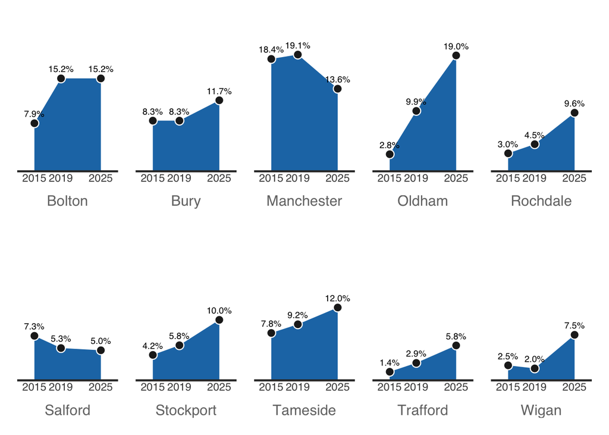

###### Source: English Indices of Deprivation, MHCLG | @traffordDataLab

#### CIPFA

#### Change in percentage of LSOAs in 1st decile of Living Environment domain, CIPFA statistical neighbours

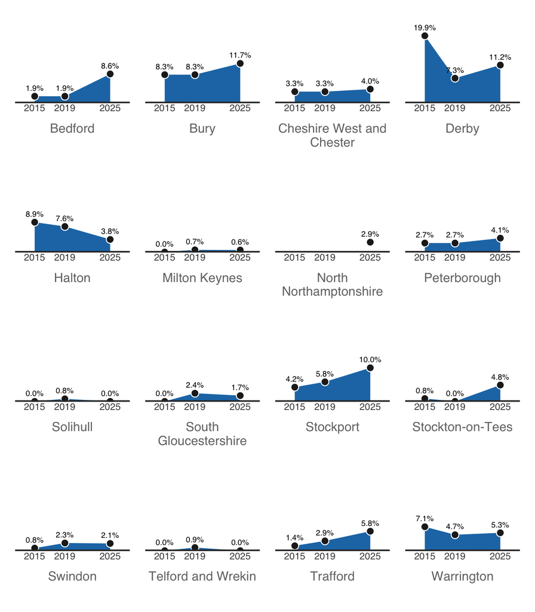

###### Source: English Indices of Deprivation, MHCLG | @traffordDataLab

#### NHS Peers

#### Change in percentage of LSOAs in 1st decile of Living Environment domain, NHS Near Neighbour peer group

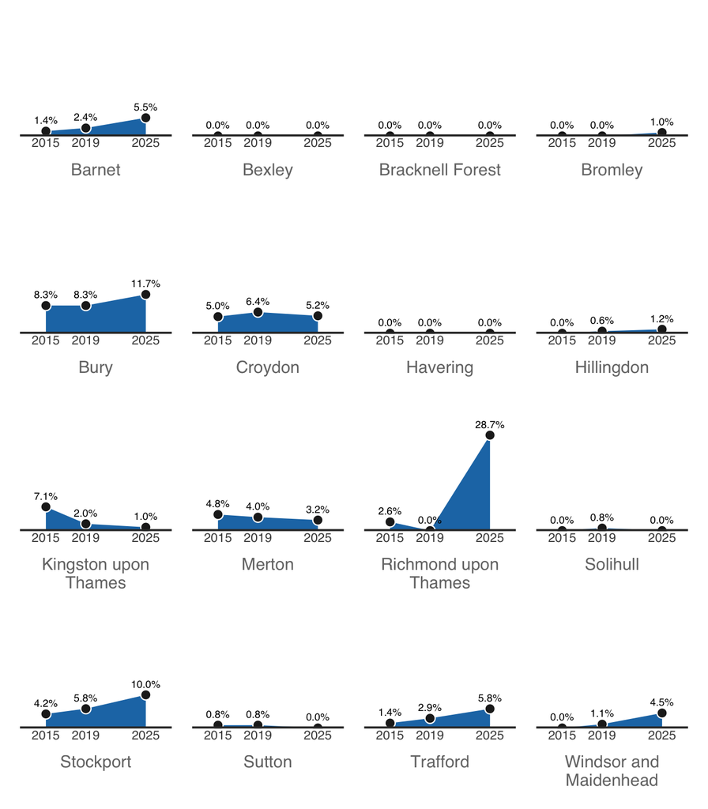

###### Source: English Indices of Deprivation, MHCLG | @traffordDataLab

1 LSOA in Stretford & Humphrey Park, 2 in Old Trafford, 1 in Sale Central, 1 in Gorse Hill & Cornbrook, 1 in Hale, 1 in Urmston and 1 in Ashton upon Mersey ward were amongst the 10% most deprived LSOAs on the Living Environment domain in England in 2025.

#### Living Environment domain 2025, LSOAs in Trafford

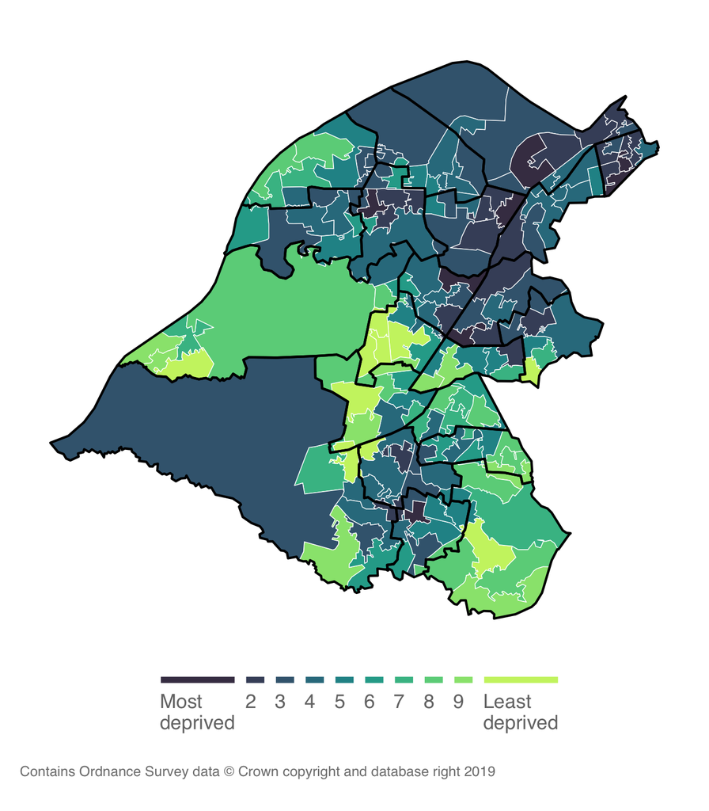

| LSOA | Ward | Decile | Rank |
| --- | --- | --- | --- |
| E01006180 | Stretford & Humphrey Park | 1 | 157 |
| E01006110 | Old Trafford | 1 | 480 |
| E01006163 | Sale Central | 1 | 1,062 |
| E01006187 | Gorse Hill & Cornbrook | 1 | 1,089 |
| E01006088 | Hale | 1 | 1,556 |
| E01006115 | Old Trafford | 1 | 1,884 |
| E01006201 | Urmston | 1 | 2,393 |
| E01006154 | Ashton upon Mersey | 1 | 3,007 |

Source: English Indices of Deprivation (2025), MHCLG | @traffordDataLab

#### Living Environment Deprivation 2025, LSOAs in Trafford

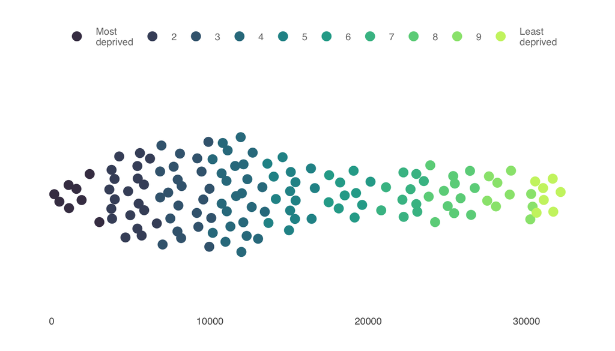

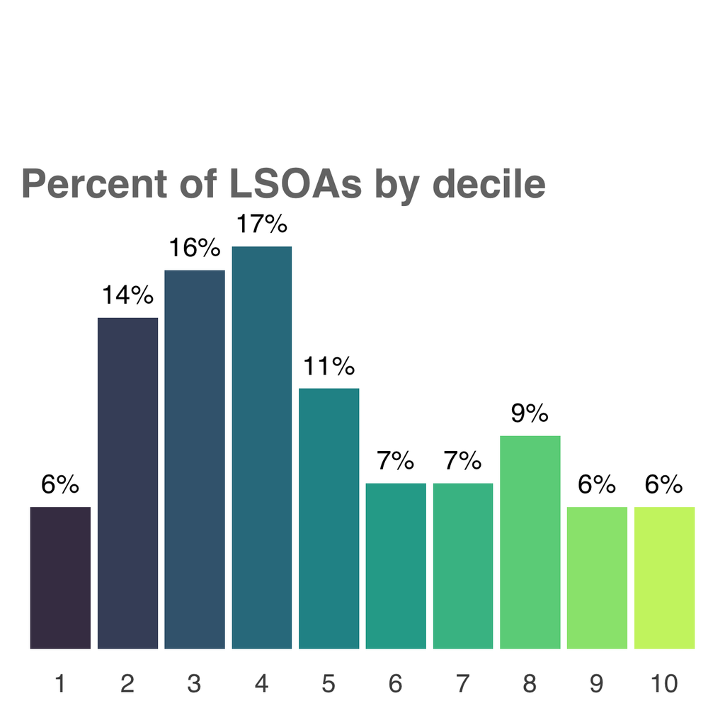

1 is most deprived  
Source: English Indices of Deprivation (2025), MHCLG | @traffordDataLab

The difference between the rank of the most deprived LSOA (157) and the least deprived LSOA (33289) on the Index of Multiple Deprivation is 33132

36 % of the LSOAs in Trafford are among the 3 most deprived deciles in England, 21.6 % of the LSOAs in Trafford are among the 3 least deprived deciles in England

## Income Deprivation Affecting Children

The Income Deprivation Affecting Children sub-domain measures the proportion of all children aged 0 to 15 living in income deprived families.

Trafford is ranked 251 out of 317 local authorities in England on the average 2025 Income Deprivation Affecting Children Index score. Trafford’s relative position was 214 out of 317 local authorities in 2019.

Click the tabs below for:

#### GM

#### Relative change in rank of average IDACI score, GM authorities

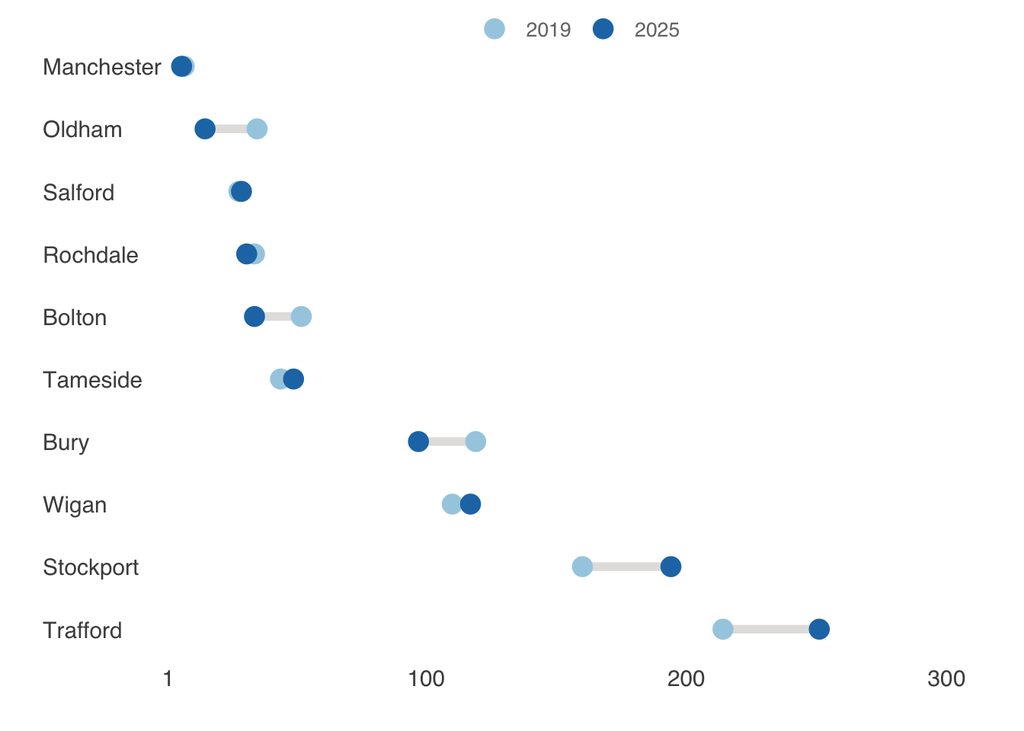

| Local authority | 2019 | 2025 | Change |
| --- | --- | --- | --- |
| Manchester | 7 | 6 | -1 |
| Oldham | 35 | 15 | -20 |
| Salford | 28 | 29 | 1 |
| Rochdale | 34 | 31 | -3 |
| Bolton | 52 | 34 | -18 |
| Tameside | 44 | 49 | 5 |
| Bury | 119 | 97 | -22 |
| Wigan | 110 | 117 | 7 |
| Stockport | 160 | 194 | 34 |
| Trafford | 214 | 251 | 37 |

Source: English Indices of Deprivation, MHCLG | @traffordDataLab

#### CIPFA

#### Relative change in rank of average IDACI score, CIPFA statistical neighbours

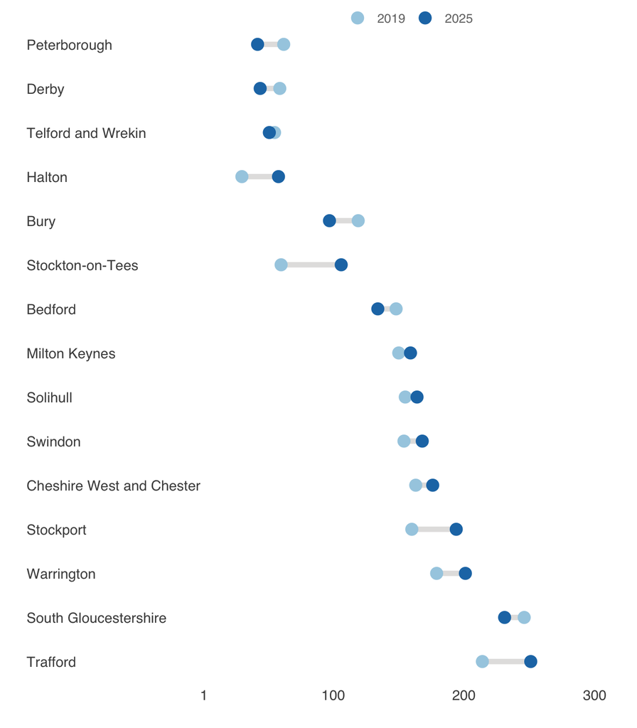

| Local authority | 2019 | 2025 | Change |
| --- | --- | --- | --- |
| Peterborough | 62 | 42 | -20 |
| Derby | 59 | 44 | -15 |
| Telford and Wrekin | 55 | 51 | -4 |
| Halton | 30 | 58 | 28 |
| Bury | 119 | 97 | -22 |
| Stockton-on-Tees | 60 | 106 | 46 |
| Bedford | 148 | 134 | -14 |
| North Northamptonshire | NA | 147 | NA |
| Milton Keynes | 150 | 159 | 9 |
| Solihull | 155 | 164 | 9 |
| Swindon | 154 | 168 | 14 |
| Cheshire West and Chester | 163 | 176 | 13 |
| Stockport | 160 | 194 | 34 |
| Warrington | 179 | 201 | 22 |
| South Gloucestershire | 246 | 231 | -15 |
| Trafford | 214 | 251 | 37 |

Source: English Indices of Deprivation, MHCLG | @traffordDataLab

#### NHS Peers

#### Relative change in rank of average IDACI score, NHS Near Neighbour peer group

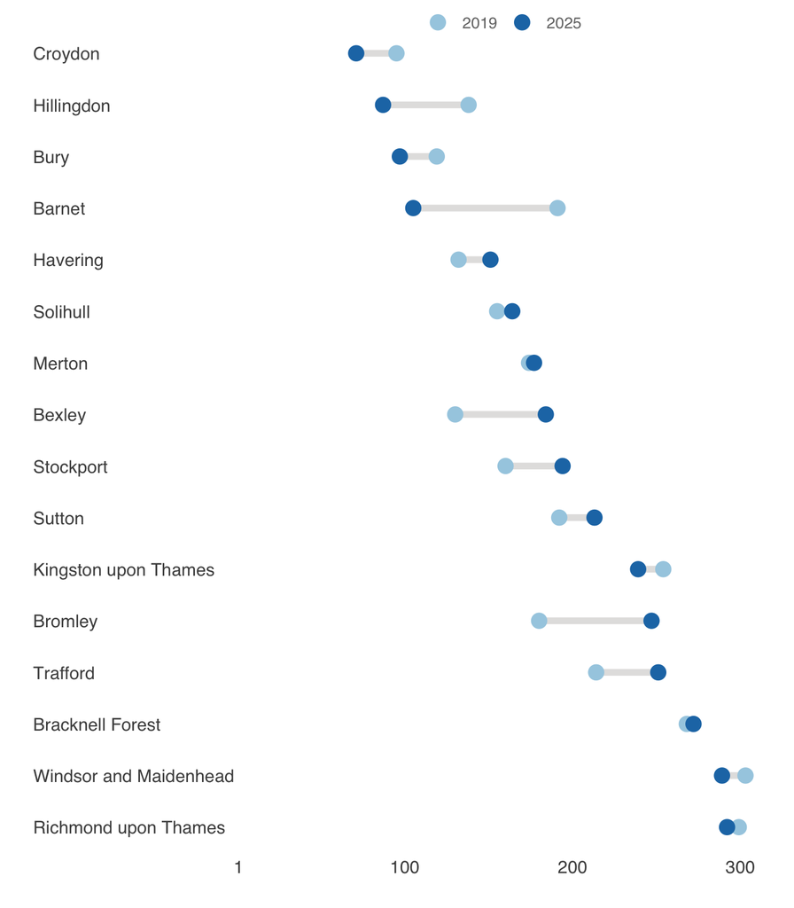

| Local authority | 2019 | 2025 | Change |
| --- | --- | --- | --- |
| Croydon | 95 | 71 | -24 |
| Hillingdon | 138 | 87 | -51 |
| Bury | 119 | 97 | -22 |
| Barnet | 191 | 105 | -86 |
| Havering | 132 | 151 | 19 |
| Solihull | 155 | 164 | 9 |
| Merton | 174 | 177 | 3 |
| Bexley | 130 | 184 | 54 |
| Stockport | 160 | 194 | 34 |
| Sutton | 192 | 213 | 21 |
| Kingston upon Thames | 254 | 239 | -15 |
| Bromley | 180 | 247 | 67 |
| Trafford | 214 | 251 | 37 |
| Bracknell Forest | 268 | 272 | 4 |
| Windsor and Maidenhead | 303 | 289 | -14 |
| Richmond upon Thames | 299 | 292 | -7 |

Source: English Indices of Deprivation, MHCLG | @traffordDataLab

The proportion of Trafford’s LSOAs ranked in the 1st decile or 10% most deprived in England was 4.3% (6 out of 139) in 2025. This represents a rise in relative deprivation since 2019 when 3.6% (5 out of 138) of LSOAs were ranked within the 1st decile.

Click the tabs below for:

#### GM

#### Change in percentage of LSOAs in 1st decile of IDACI supplementary index, GM authorities

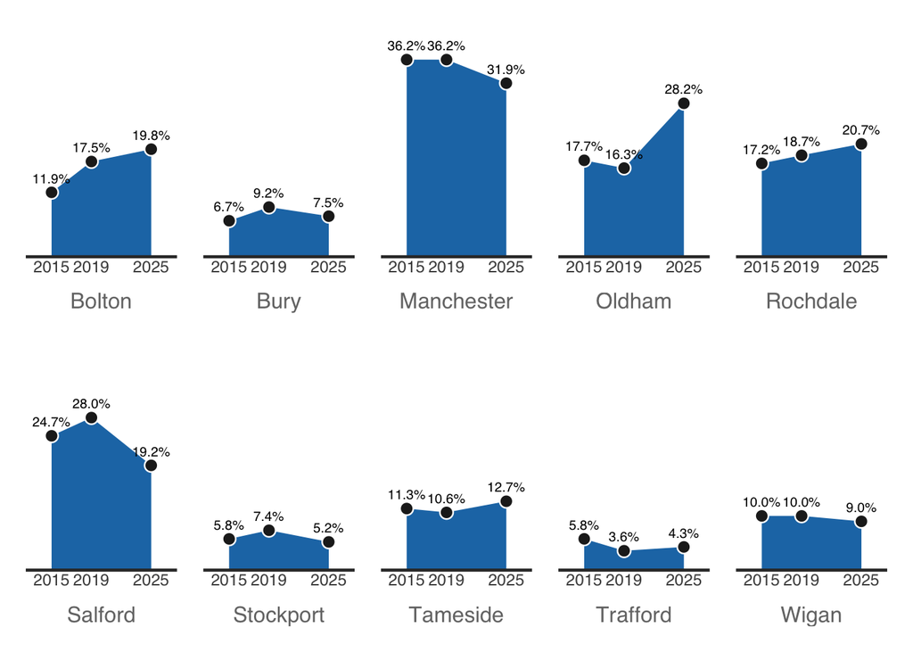

###### Source: English Indices of Deprivation, MHCLG | @traffordDataLab

#### CIPFA

#### Change in percentage of LSOAs in 1st decile of IDACI supplementary index, CIPFA statistical neighbours

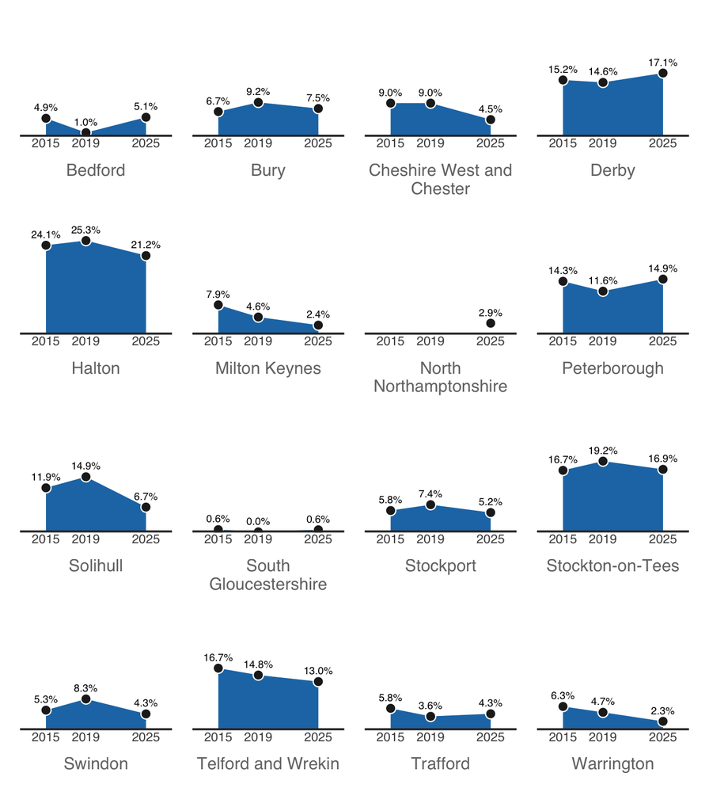

###### Source: English Indices of Deprivation, MHCLG | @traffordDataLab

#### NHS Peers

#### Change in percentage of LSOAs in 1st decile of IDACI supplementary index, NHS Near Neighbour peer group

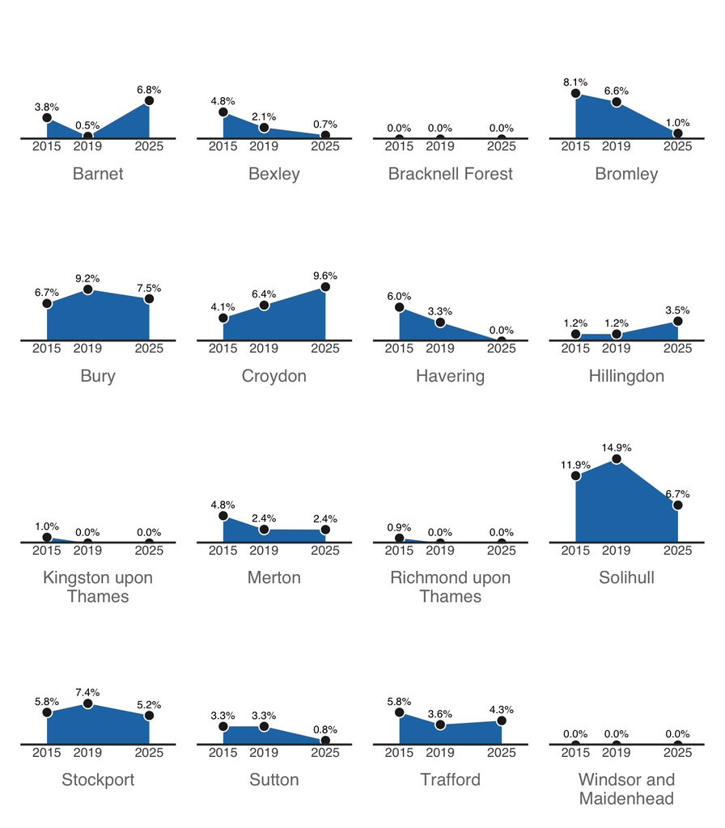

###### Source: English Indices of Deprivation, MHCLG | @traffordDataLab

2 LSOAs in Manor, 3 in Bucklow-St Martins and 1 in Old Trafford ward were amongst the 10% most deprived LSOAs on the Income Deprivation Affecting Children sub-domain in England in 2025.

Trafford 019E in Manor ward and Trafford 017E in Bucklow-St Martins ward rank 699 and 712 respectively out of 33,755 LSOAs nationally on the Income Deprivation Affecting Children sub-domain with with more than 80% of children aged 0 to 15 living in income deprived families. In 2019, the same LSOAs was ranked 1,899 and 805 out of 32,844 LSOAs respectivley nationally with 37.8% and 44.1% of children aged 0 to 15 living in income deprived families.

#### IDACI 2025, LSOAs in Trafford

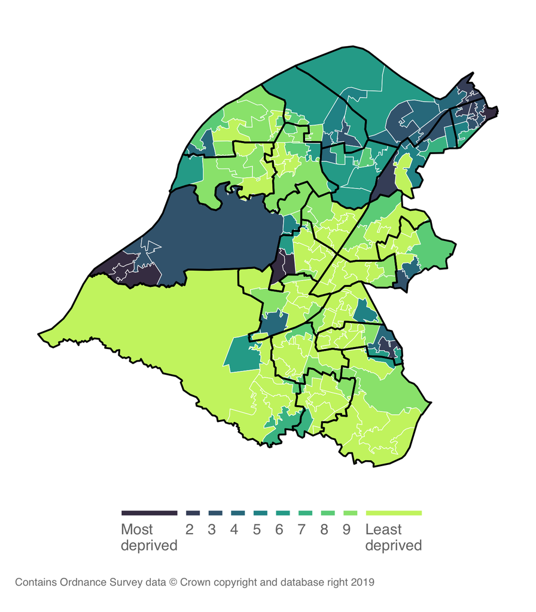

| LSOA | Ward | Decile | Rank |
| --- | --- | --- | --- |
| E01006168 | Manor | 1 | 699 |
| E01006108 | Bucklow-St Martins | 1 | 712 |
| E01006105 | Bucklow-St Martins | 1 | 955 |
| E01006109 | Old Trafford | 1 | 1,795 |
| E01006106 | Bucklow-St Martins | 1 | 1,941 |
| E01006167 | Manor | 1 | 3,119 |

Source: English Indices of Deprivation (2025), MHCLG | @traffordDataLab

#### Income Deprivation Affecting Children 2025, LSOAs in Trafford

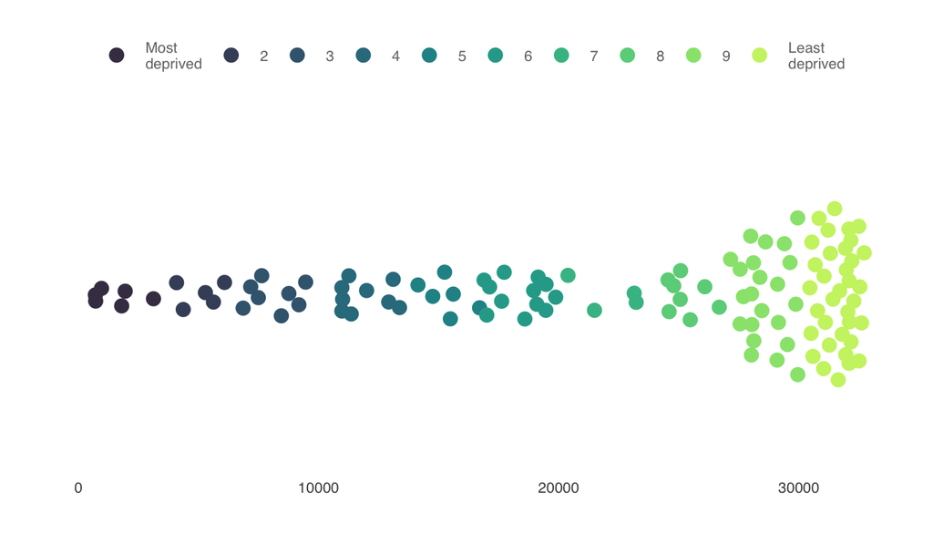

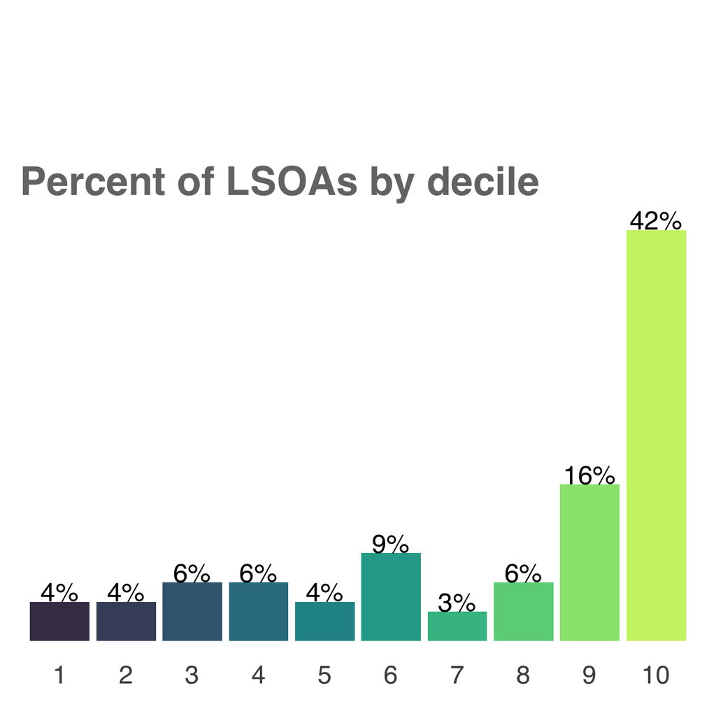

1 is most deprived  
Source: English Indices of Deprivation (2025), MHCLG | @traffordDataLab

The difference between the rank of the most deprived LSOA (699) and the least deprived LSOA (33742) on the Index of Multiple Deprivation is 33043

13.7 % of the LSOAs in Trafford are among the 3 most deprived deciles in England, 64 % of the LSOAs in Trafford are among the 3 least deprived deciles in England

## Income Deprivation Affecting Older People

The Income Deprivation Affecting Older People sub-domain measures the proportion of all those aged 60 or over who experience income deprivation.

Trafford is ranked 138 out of 317 local authorities in England on the average 2025 Income Deprivation Affecting Older People Index score. Trafford’s relative position was 134 out of 317 local authorities in 2019.

Click the tabs below for:

#### GM

#### Relative change in rank of average IDAOPI score, GM authorities

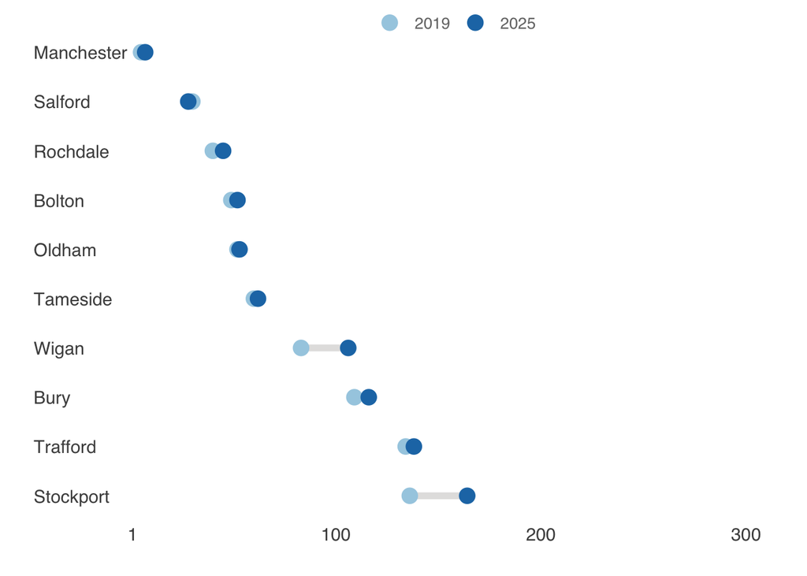

| Local authority | 2019 | 2025 | Change |
| --- | --- | --- | --- |
| Manchester | 5 | 7 | 2 |
| Salford | 30 | 28 | -2 |
| Rochdale | 40 | 45 | 5 |
| Bolton | 49 | 52 | 3 |
| Oldham | 52 | 53 | 1 |
| Tameside | 60 | 62 | 2 |
| Wigan | 83 | 106 | 23 |
| Bury | 109 | 116 | 7 |
| Trafford | 134 | 138 | 4 |
| Stockport | 136 | 164 | 28 |

Source: English Indices of Deprivation, MHCLG | @traffordDataLab

#### CIPFA

#### Relative change in rank of average IDAOPI score, CIPFA statistical neighbours

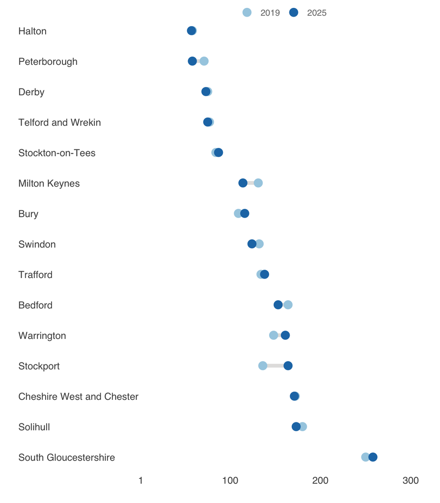

| Local authority | 2019 | 2025 | Change |
| --- | --- | --- | --- |
| Halton | 58 | 57 | -1 |
| Peterborough | 71 | 58 | -13 |
| Derby | 75 | 73 | -2 |
| Telford and Wrekin | 77 | 75 | -2 |
| Stockton-on-Tees | 84 | 87 | 3 |
| Milton Keynes | 131 | 114 | -17 |
| Bury | 109 | 116 | 7 |
| Swindon | 132 | 124 | -8 |
| Trafford | 134 | 138 | 4 |
| Bedford | 164 | 153 | -11 |
| North Northamptonshire | NA | 154 | NA |
| Warrington | 148 | 161 | 13 |
| Stockport | 136 | 164 | 28 |
| Cheshire West and Chester | 172 | 171 | -1 |
| Solihull | 180 | 173 | -7 |
| South Gloucestershire | 250 | 258 | 8 |

Source: English Indices of Deprivation, MHCLG | @traffordDataLab

#### NHS Peers

#### Relative change in rank of average IDAOPI score, NHS Near Neighbour peer group

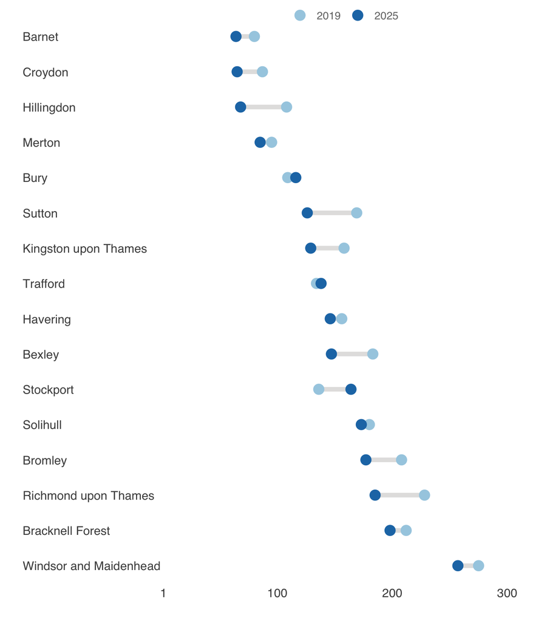

| Local authority | 2019 | 2025 | Change |
| --- | --- | --- | --- |
| Barnet | 80 | 64 | -16 |
| Croydon | 87 | 65 | -22 |
| Hillingdon | 108 | 68 | -40 |
| Merton | 95 | 85 | -10 |
| Bury | 109 | 116 | 7 |
| Sutton | 169 | 126 | -43 |
| Kingston upon Thames | 158 | 129 | -29 |
| Trafford | 134 | 138 | 4 |
| Havering | 156 | 146 | -10 |
| Bexley | 183 | 147 | -36 |
| Stockport | 136 | 164 | 28 |
| Solihull | 180 | 173 | -7 |
| Bromley | 208 | 177 | -31 |
| Richmond upon Thames | 228 | 185 | -43 |
| Bracknell Forest | 212 | 198 | -14 |
| Windsor and Maidenhead | 275 | 257 | -18 |

Source: English Indices of Deprivation, MHCLG | @traffordDataLab

The proportion of Trafford’s LSOAs ranked in the 1st decile or 10% most deprived in England was 7.2% (10 out of 139) in 2025. This represents no change on 2019 when 7.2% (10 out of 138) of LSOAs were ranked within the 1st decile.

Click the tabs below for:

#### GM

#### Change in percentage of LSOAs in 1st decile of IDAOPI supplementary index, GM authorities

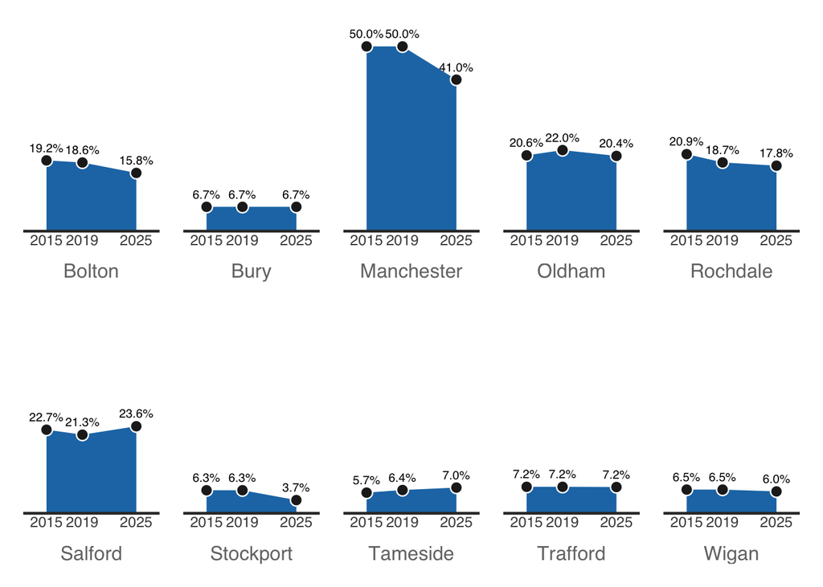

###### Source: English Indices of Deprivation, MHCLG | @traffordDataLab

#### CIPFA

#### Change in percentage of LSOAs in 1st decile of IDAOPI supplementary index, CIPFA statistical neighbours

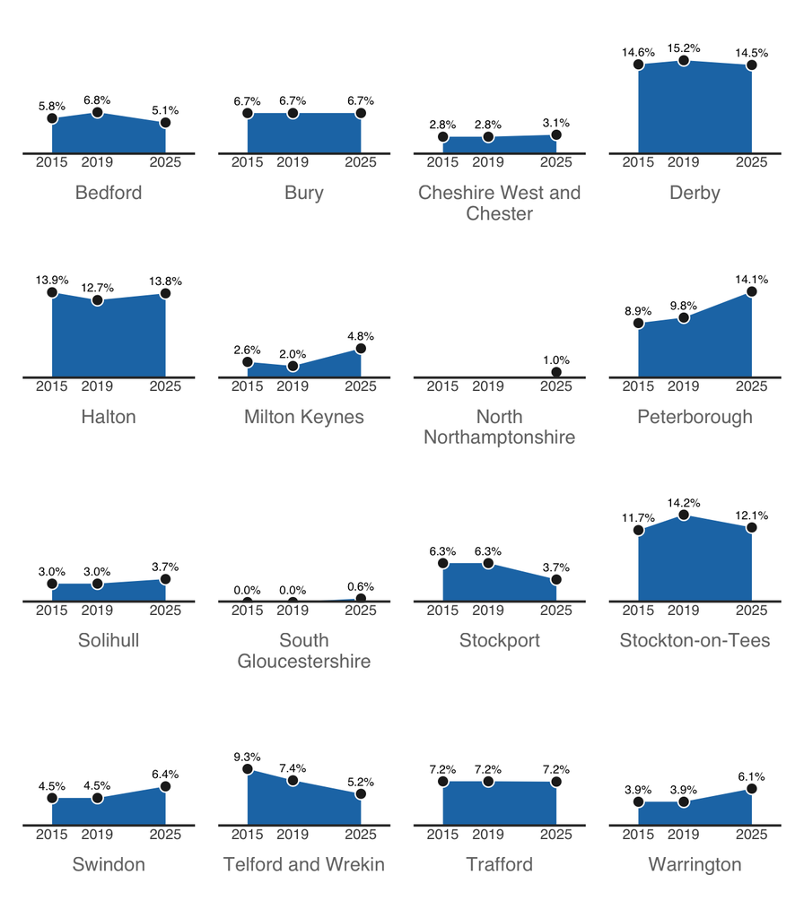

###### Source: English Indices of Deprivation, MHCLG | @traffordDataLab

#### NHS Peers

#### Change in percentage of LSOAs in 1st decile of IDAOPI supplementary index, NHS Near Neighbour peer group

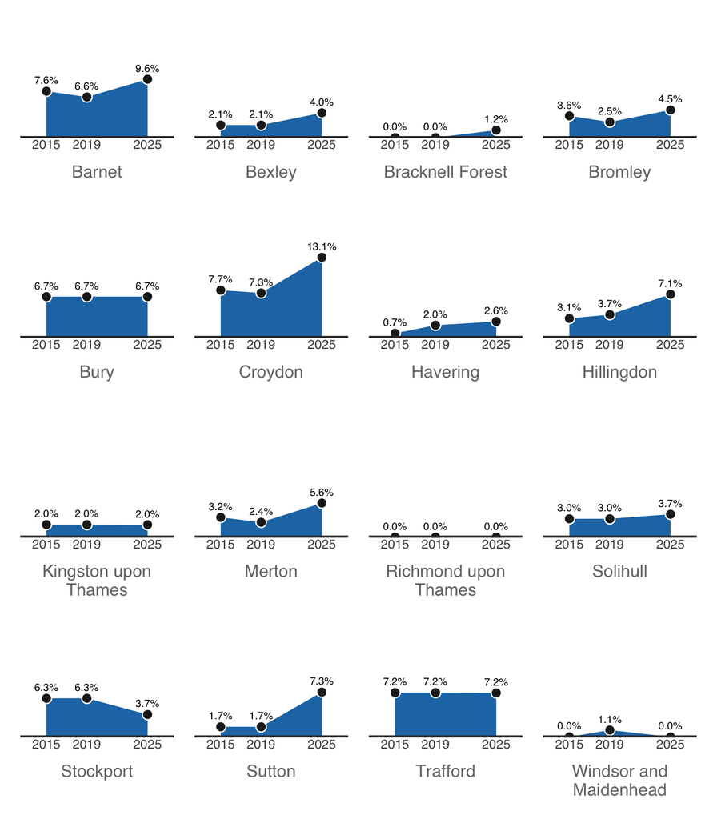

#### IDAOPI 2025, LSOAs in Trafford

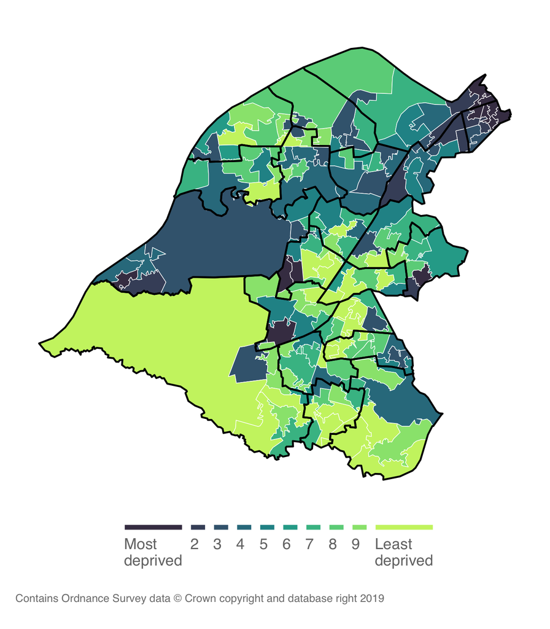

| LSOA | Ward | Decile | Rank |
| --- | --- | --- | --- |
| E01034000 | Gorse Hill & Cornbrook | 1 | 45 |
| E01006112 | Old Trafford | 1 | 513 |
| E01006111 | Old Trafford | 1 | 710 |
| E01006109 | Old Trafford | 1 | 894 |
| E01006108 | Bucklow-St Martins | 1 | 1,100 |
| E01034001 | Gorse Hill & Cornbrook | 1 | 1,556 |
| E01006167 | Manor | 1 | 2,267 |
| E01006175 | Sale Moor | 1 | 2,538 |
| E01006092 | Broadheath | 1 | 2,998 |
| E01006168 | Manor | 1 | 3,347 |

Source: English Indices of Deprivation (2025), MHCLG | @traffordDataLab